# Lab 5: Bikeshare SpaceTime Prediction

CPLN 5080 - Spring 2026

Author

Parker Otto

Published

April 19, 2026

# INTRODUCTION

## The Rebalancing Challenge in Philadelphia

Philadelphia’s Indego bike share system faces the same operational challenge as every bike share system: **rebalancing bikes to meet anticipated demand**.

Imagine you’re an Indego operations manager at 6:00 AM on a Monday morning. You have: - 200 stations across Philadelphia - Limited trucks and staff for moving bikes - 2-3 hours before morning rush hour demand peaks - **The question:** Which stations will run out of bikes by 8:30 AM?

This lab will teach you to build predictive models that forecast bike share demand across **space** (different stations) and **time** (different hours) to help solve this operational problem.

## Learning Objectives

By the end of this assignment, you will be able to:

1. **Understand panel data structure** for space-time analysis
2. **Create temporal lag variables** to capture demand persistence
3. **Build multiple predictive models** with increasing complexity
4. **Validate models temporally** (train on past, test on future)
5. **Analyze prediction errors** in both space and time
6. **Engineer new features** based on error patterns
7. **Critically evaluate** when prediction errors matter most

## Assignment Structure

**Part 1 (In-Class/Together):** Work through Q1 2025 data following this code

**Part 2 (HW5 - Teams of 2):** - Download a different quarter of Indego data (Q2, Q3, or Q4 2025) - Apply the same workflow to your quarter - Analyze error patterns in your quarter - Add 2-3 new features to improve the model - Write a brief report on what you learned

#SET UP

```r
library(tidyverse)
library(lubridate)
library(sf)
library(tigris)
library(tidycensus)
library(riem)  # For Philadelphia weather from ASOS stations

library(viridis) # color scales for visualization
library(knitr)
library(kableExtra)
library(patchwork)


library(here)
options(scipen = 999) # Get rid of scientific notation to make it look tidier
```

```r
plotTheme <- theme_minimal() +
  theme(
    plot.title    = element_text(size = 14, face = "bold"),
    plot.subtitle = element_text(size = 10),
    plot.caption  = element_text(size = 8),
    axis.text.x   = element_text(size = 10, angle = 45, hjust = 1),
    axis.text.y   = element_text(size = 10),
    axis.title    = element_text(size = 11, face = "bold"),
    panel.grid.major = element_line(colour = "#D0D0D0", linewidth = 0.2),
    panel.grid.minor = element_blank(),
    axis.ticks    = element_blank(),
    legend.position = "right"
  )

mapTheme <- theme_void() +
  theme(
    plot.title    = element_text(size = 14, face = "bold"),
    plot.subtitle = element_text(size = 10),
    plot.caption  = element_text(size = 8),
    legend.position  = "right",
    plot.margin      = margin(1, 1, 1, 1, "cm"),
    legend.key.height = unit(1, "cm"),
    legend.key.width  = unit(0.2, "cm")
  )

palette5 <- c("#eff3ff", "#bdd7e7", "#6baed6", "#3182bd", "#08519c")
```

```r
census_api_key(Sys.getenv("a05b265afea2fb4dfbd350edadaf50fb30255de8"))

#Use the following code if you're not able to access the key in your environment
#census_api_key("yourkeyhere", install=TRUE, overwrite=TRUE)
```

# IMPORT AND PREP DATA

## Load Indego Trip Data (Q1 2025)

**Note for HW5:** You’ll download a different quarter from: https://www.rideindego.com/about/data/

```r
# Read Q1 2025 data
indego <- read_csv("indego-trips-2025-q1.csv")

# Quick look at the data
glimpse(indego)
```

```
Rows: 201,588
Columns: 15
$ trip_id             <dbl> 1123985990, 1123986350, 1124202498, 1123986241, 11…
$ duration            <dbl> 5, 14, 894, 9, 13, 11, 15, 19, 20, 24, 26, 11, 12,…
$ start_time          <chr> "1/1/2025 0:00", "1/1/2025 0:04", "1/1/2025 0:05",…
$ end_time            <chr> "1/1/2025 0:05", "1/1/2025 0:18", "1/1/2025 14:59"…
$ start_station       <dbl> 3371, 3344, 3021, 3253, 3182, 3346, 3049, 3112, 31…
$ start_lat           <dbl> 39.95340, 39.95961, 39.95390, 39.93074, 39.95081, …
$ start_lon           <dbl> -75.15430, -75.23354, -75.16902, -75.18924, -75.16…
$ end_station         <dbl> 3378, 3294, 3073, 3253, 3249, 3000, 3100, 3035, 33…
$ end_lat             <dbl> 39.95238, 39.95174, 39.96143, 39.93074, 39.95784, …
$ end_lon             <dbl> -75.14728, -75.17063, -75.15242, -75.18924, -75.19…
$ bike_id             <chr> "22580", "31417", "31393", "31434", "22872", "1187…
$ plan_duration       <dbl> 30, 365, 1, 30, 1, 365, 30, 30, 365, 365, 30, 365,…
$ trip_route_category <chr> "One Way", "One Way", "One Way", "Round Trip", "On…
$ passholder_type     <chr> "Indego30", "Indego365", "Walk-up", "Indego30", "W…
$ bike_type           <chr> "electric", "electric", "electric", "electric", "e…
```

**Pause here** Look at the data. What do you suspect the coordinate system is? What do you notice about the date and time structure?

## Examine the Data Structure

```r
# How many trips?
cat("Total trips in Q1 2025:", nrow(indego), "\n")
```

```
Total trips in Q1 2025: 201588
```

```r
# Date range
cat("Date range:",
    min(mdy_hm(indego$start_time)), "to",
    max(mdy_hm(indego$start_time)), "\n")
```

```
Date range: 1735689600 to 1743464880
```

```r
# How many unique stations?
cat("Unique start stations:", length(unique(indego$start_station)), "\n")
```

```
Unique start stations: 265
```

```r
# Trip types
table(indego$trip_route_category)
```

```
   One Way Round Trip
    190792      10796
```

```r
# Passholder types
table(indego$passholder_type)
```

```
  Day Pass   Indego30  Indego365 IndegoFlex    Walk-up
      5494      94044      91628          3      10419
```

```r
# Bike types
table(indego$bike_type)
```

```
electric standard
  129561    72027
```

## Create Time Bins

We need to aggregate trips into hourly intervals for our panel data structure. Read up on the lubridate library for more information on the date/time data extraction.

```r
indego <- indego %>%
  mutate(
    # Parse datetime
    start_datetime = mdy_hm(start_time),
    end_datetime = mdy_hm(end_time),

    # Create hourly bins
    interval60 = floor_date(start_datetime, unit = "hour"),

    # Extract time features
    week = week(interval60),
    month = month(interval60, label = TRUE),
    dotw = wday(interval60, label = TRUE),
    hour = hour(interval60),
    date = as.Date(interval60),

    # Create useful indicators
    weekend = ifelse(dotw %in% c("Sat", "Sun"), 1, 0),
    rush_hour = ifelse(hour %in% c(7, 8, 9, 16, 17, 18), 1, 0)
  )

# Look at temporal features
head(indego %>% select(start_datetime, interval60, week, dotw, hour, weekend))
```

```
# A tibble: 6 × 6
  start_datetime      interval60           week dotw   hour weekend
  <dttm>              <dttm>              <dbl> <ord> <int>   <dbl>
1 2025-01-01 00:00:00 2025-01-01 00:00:00     1 Wed       0       0
2 2025-01-01 00:04:00 2025-01-01 00:00:00     1 Wed       0       0
3 2025-01-01 00:05:00 2025-01-01 00:00:00     1 Wed       0       0
4 2025-01-01 00:05:00 2025-01-01 00:00:00     1 Wed       0       0
5 2025-01-01 00:08:00 2025-01-01 00:00:00     1 Wed       0       0
6 2025-01-01 00:14:00 2025-01-01 00:00:00     1 Wed       0       0
```

**Question** Explain the interval60 feature to someone else at your table.

#EDA OF INDEGO DATA

## Trips Over Time

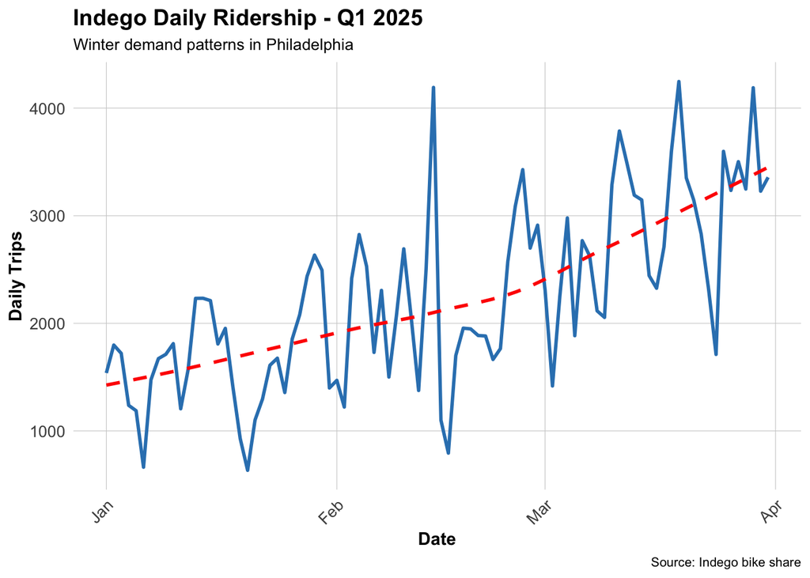

```r
# Daily trip counts
daily_trips <- indego %>%
  group_by(date) %>%
  summarize(trips = n())

ggplot(daily_trips, aes(x = date, y = trips)) +
  geom_line(color = "#3182bd", linewidth = 1) +
  geom_smooth(se = FALSE, color = "red", linetype = "dashed") +
  labs(
    title = "Indego Daily Ridership - Q1 2025",
    subtitle = "Winter demand patterns in Philadelphia",
    x = "Date",
    y = "Daily Trips",
    caption = "Source: Indego bike share"
  ) +
  plotTheme
```

**Question:** What patterns do you see? How does ridership change over time?

Notice a big spike in Februrary of 2025 (the 14th - not just Valentine’s Day)? Was anybody in Philly last Feb? What closed everything and cancelled my PPA class? … Hint: Fly Eagles Fly

Let’s investigate…compare the 14th to all other Friday’s in the data…what did you find? Keep this in mind for future Feature Engineering.

```r
fly_eagles_fly <- daily_trips %>% filter(date == "2025-02-14")

typical_boring_friday <- indego %>%
  filter(dotw == "Fri", date != "2025-02-14") %>%
  group_by(date) %>%
  summarize(trips = n()) %>%
  summarize(avg_friday_trips = mean(trips))

print(fly_eagles_fly)
```

```
# A tibble: 1 × 2
  date       trips
  <date>     <int>
1 2025-02-14  4192
```

```r
print(typical_boring_friday)
```

```
# A tibble: 1 × 1
  avg_friday_trips
             <dbl>
1            2319.
```

## Hourly Patterns

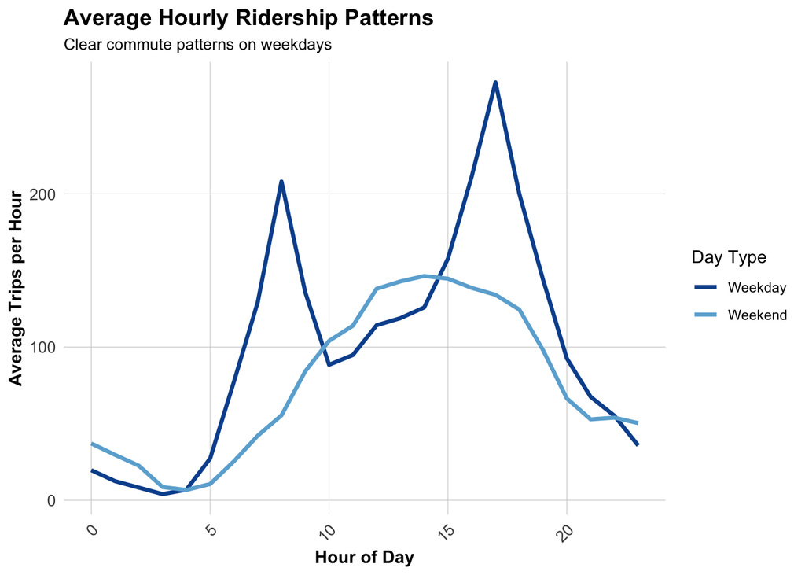

```r
# Average trips by hour and day type
hourly_patterns <- indego %>%
  group_by(hour, weekend) %>%
  summarize(avg_trips = n() / n_distinct(date)) %>%
  mutate(day_type = ifelse(weekend == 1, "Weekend", "Weekday"))

ggplot(hourly_patterns, aes(x = hour, y = avg_trips, color = day_type)) +
  geom_line(linewidth = 1.2) +
  scale_color_manual(values = c("Weekday" = "#08519c", "Weekend" = "#6baed6")) +
  labs(
    title = "Average Hourly Ridership Patterns",
    subtitle = "Clear commute patterns on weekdays",
    x = "Hour of Day",
    y = "Average Trips per Hour",
    color = "Day Type"
  ) +
  plotTheme
```

**Question:** When are the peak hours? How do weekends differ from weekdays?

## Top Stations

```r
# Most popular origin stations
top_stations <- indego %>%
  count(start_station, start_lat, start_lon, name = "trips") %>%
  arrange(desc(trips)) %>%
  head(20)

kable(top_stations,
      caption = "Top 20 Indego Stations by Trip Origins",
      format.args = list(big.mark = ",")) %>%
  kable_styling(bootstrap_options = c("striped", "hover"))
```

Top 20 Indego Stations by Trip Origins

| start_station | start_lat | start_lon | trips |
| --- | --- | --- | --- |
| 3,010 | 39.94711 | -75.16618 | 3,999 |
| 3,032 | 39.94527 | -75.17971 | 2,842 |
| 3,359 | 39.94888 | -75.16978 | 2,699 |
| 3,020 | 39.94855 | -75.19007 | 2,673 |
| 3,208 | 39.95048 | -75.19324 | 2,503 |
| 3,244 | 39.93865 | -75.16674 | 2,486 |
| 3,066 | 39.94561 | -75.17348 | 2,396 |
| 3,362 | 39.94816 | -75.16226 | 2,387 |
| 3,012 | 39.94218 | -75.17747 | 2,361 |
| 3,028 | 39.94061 | -75.14958 | 2,348 |
| 3,161 | 39.95486 | -75.18091 | 2,278 |
| 3,101 | 39.94295 | -75.15955 | 2,274 |
| 3,295 | 39.95028 | -75.16027 | 2,160 |
| 3,054 | 39.96250 | -75.17420 | 2,123 |
| 3,185 | 39.95169 | -75.15888 | 2,116 |
| 3,038 | 39.94781 | -75.19409 | 2,111 |
| 3,203 | 39.94077 | -75.17227 | 2,106 |
| 3,059 | 39.96244 | -75.16121 | 2,027 |
| 3,022 | 39.95472 | -75.18323 | 2,014 |
| 3,063 | 39.94633 | -75.16980 | 2,014 |

# PUT DATA IN CONTEXT

## Load Philadelphia Census Data

We’ll get census tract data to add demographic context to our stations.

```r
# Get Philadelphia census tracts
philly_census <- get_acs(
  geography = "tract",
  variables = c(
    "B01003_001",  # Total population
    "B19013_001",  # Median household income
    "B08301_001",  # Total commuters
    "B08301_010",  # Commute by transit
    "B02001_002",  # White alone
    "B25077_001"   # Median home value
  ),
  state = "PA",
  county = "Philadelphia",
  year = 2022,
  geometry = TRUE,
  output = "wide"
) %>%
  rename(
    Total_Pop = B01003_001E,
    Med_Inc = B19013_001E,
    Total_Commuters = B08301_001E,
    Transit_Commuters = B08301_010E,
    White_Pop = B02001_002E,
    Med_Home_Value = B25077_001E
  ) %>%
  mutate(
    Percent_Taking_Transit = (Transit_Commuters / Total_Commuters) * 100,
    Percent_White = (White_Pop / Total_Pop) * 100
  ) %>%
  st_transform(crs = 4326)  #transforming to WGS84 for lat/lon matching, currently in NAD83
# Check the data
glimpse(philly_census)
```

```
Rows: 408
Columns: 17
$ GEOID                  <chr> "42101001500", "42101001800", "42101002802", "4…
$ NAME                   <chr> "Census Tract 15; Philadelphia County; Pennsylv…
$ Total_Pop              <dbl> 3251, 3300, 5720, 4029, 4415, 1815, 3374, 2729,…
$ B01003_001M            <dbl> 677, 369, 796, 437, 853, 210, 480, 734, 763, 11…
$ Med_Inc                <dbl> 110859, 114063, 78871, 61583, 32347, 48581, 597…
$ B19013_001M            <dbl> 24975, 30714, 20396, 22293, 4840, 13812, 6278, …
$ Total_Commuters        <dbl> 2073, 2255, 3032, 2326, 1980, 969, 2427, 708, 2…
$ B08301_001M            <dbl> 387, 308, 478, 383, 456, 189, 380, 281, 456, 68…
$ Transit_Commuters      <dbl> 429, 123, 685, 506, 534, 192, 658, 218, 438, 51…
$ B08301_010M            <dbl> 188, 66, 219, 144, 285, 71, 278, 184, 176, 235,…
$ White_Pop              <dbl> 2185, 2494, 3691, 3223, 182, 984, 2111, 231, 35…
$ B02001_002M            <dbl> 268, 381, 592, 380, 88, 190, 463, 112, 238, 778…
$ Med_Home_Value         <dbl> 568300, 605000, 350600, 296400, 76600, 289700, …
$ B25077_001M            <dbl> 58894, 34876, 12572, 22333, 10843, 118720, 1506…
$ geometry               <MULTIPOLYGON [°]> MULTIPOLYGON (((-75.16558 3..., MU…
$ Percent_Taking_Transit <dbl> 20.694645, 5.454545, 22.592348, 21.754084, 26.9…
$ Percent_White          <dbl> 67.2100892, 75.5757576, 64.5279720, 79.9950360,…
```

## Map Philadelphia Context

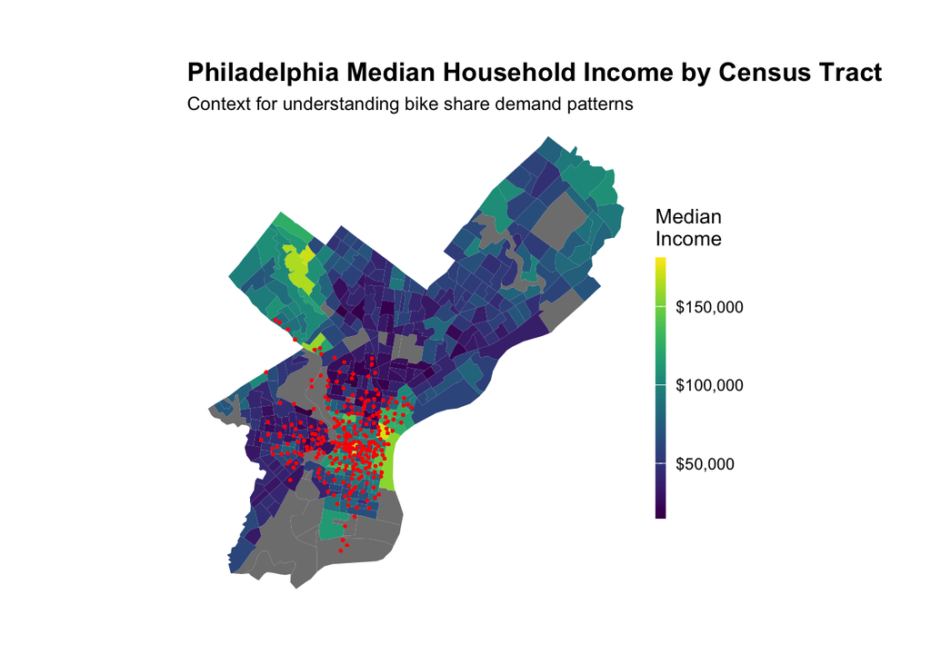

```r
# Map median income
ggplot() +
  geom_sf(data = philly_census, aes(fill = Med_Inc), color = NA) +
  scale_fill_viridis(
    option = "viridis",
    name = "Median\nIncome",
    labels = scales::dollar
  ) +
  labs(
    title = "Philadelphia Median Household Income by Census Tract",
    subtitle = "Context for understanding bike share demand patterns"
  ) +
  # Stations
  geom_point(
    data = indego,
    aes(x = start_lon, y = start_lat),
    color = "red", size = 0.25, alpha = 0.6
  ) +
  mapTheme
```

**Question** These data are in WGS84. If you wanted to calculate a spatial distance-based variable, like a buffer, should you use the dataset as it?

## Join Census Data to Stations

We’ll spatially join census characteristics to each bike station.

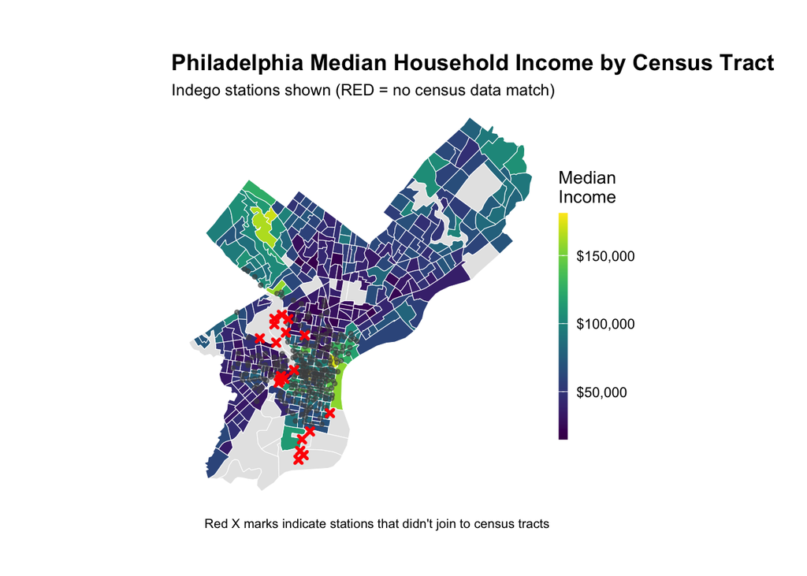

```r
# Create sf object for stations
stations_sf <- indego %>%
  distinct(start_station, start_lat, start_lon) %>%
  filter(!is.na(start_lat), !is.na(start_lon)) %>%
  st_as_sf(coords = c("start_lon", "start_lat"), crs = 4326)

# Spatial join to get census tract for each station
stations_census <- st_join(stations_sf, philly_census, left = TRUE) %>%
  st_drop_geometry()

# Look at the result - investigate whether all of the stations joined to census data -- according to the map above there are stations in non-residential tracts.

stations_for_map <- indego %>%
  distinct(start_station, start_lat, start_lon) %>%
  filter(!is.na(start_lat), !is.na(start_lon)) %>%
  left_join(
    stations_census %>% select(start_station, Med_Inc),
    by = "start_station"
  ) %>%
  mutate(has_census = !is.na(Med_Inc))

# Add back to trip data
indego_census <- indego %>%
  left_join(
    stations_census %>%
      select(start_station, Med_Inc, Percent_Taking_Transit,
             Percent_White, Total_Pop),
    by = "start_station"
  )


# Prepare data for visualization
stations_for_map <- indego %>%
  distinct(start_station, start_lat, start_lon) %>%
  filter(!is.na(start_lat), !is.na(start_lon)) %>%
  left_join(
    stations_census %>% select(start_station, Med_Inc),
    by = "start_station"
  ) %>%
  mutate(has_census = !is.na(Med_Inc))

# Create the map showing problem stations
ggplot() +
  geom_sf(data = philly_census, aes(fill = Med_Inc), color = "white", size = 0.1) +
  scale_fill_viridis(
    option = "viridis",
    name = "Median\nIncome",
    labels = scales::dollar,
    na.value = "grey90"
  ) +
  # Stations with census data (small grey dots)
  geom_point(
    data = stations_for_map %>% filter(has_census),
    aes(x = start_lon, y = start_lat),
    color = "grey30", size = 1, alpha = 0.6
  ) +
  # Stations WITHOUT census data (red X marks the spot)
  geom_point(
    data = stations_for_map %>% filter(!has_census),
    aes(x = start_lon, y = start_lat),
    color = "red", size = 1, shape = 4, stroke = 1.5
  ) +
  labs(
    title = "Philadelphia Median Household Income by Census Tract",
    subtitle = "Indego stations shown (RED = no census data match)",
    caption = "Red X marks indicate stations that didn't join to census tracts"
  ) +
  mapTheme
```

## Dealing with missing data

We need to decide what to do with the non-residential bike share stations. For this example, we are going to remove them – this is not necessarily the right way to do things always, but for the sake of simplicity, we are narrowing our scope to only stations in residential neighborhoods. We might opt to create a separate model for non-residential stations..

```r
# Identify which stations to keep
valid_stations <- stations_census %>%
  filter(!is.na(Med_Inc)) %>%
  pull(start_station)

# Filter trip data to valid stations only
indego_census <- indego %>%
  filter(start_station %in% valid_stations) %>%
  left_join(
    stations_census %>%
      select(start_station, Med_Inc, Percent_Taking_Transit,
             Percent_White, Total_Pop),
    by = "start_station"
  )
```

## Get Weather Data

Weather significantly affects bike share demand! Let’s get hourly weather for Philadelphia.

```r
# Get weather from Philadelphia International Airport (KPHL)
# This covers Q1 2025: January 1 - March 31
weather_data <- riem_measures(
  station = "PHL",  # Philadelphia International Airport
  date_start = "2025-01-01",
  date_end = "2025-03-31"
)

# Process weather data
weather_processed <- weather_data %>%
  mutate(
    interval60 = floor_date(valid, unit = "hour"),
    Temperature = tmpf,  # Temperature in Fahrenheit
    Precipitation = ifelse(is.na(p01i), 0, p01i),  # Hourly precip in inches
    Wind_Speed = sknt  # Wind speed in knots
  ) %>%
  select(interval60, Temperature, Precipitation, Wind_Speed) %>%
  distinct(interval60, .keep_all = TRUE)

# Check for missing hours and interpolate if needed
weather_complete <- weather_processed %>%
  complete(interval60 = seq(min(interval60), max(interval60), by = "hour")) %>%
  fill(Temperature, Precipitation, Wind_Speed, .direction = "down")

# Look at the weather
summary(weather_complete %>% select(Temperature, Precipitation, Wind_Speed))
```

```
  Temperature    Precipitation        Wind_Speed
 Min.   :10.00   Min.   :0.000000   Min.   : 0.000
 1st Qu.:30.00   1st Qu.:0.000000   1st Qu.: 6.000
 Median :37.00   Median :0.000000   Median : 8.000
 Mean   :38.36   Mean   :0.001327   Mean   : 9.308
 3rd Qu.:46.00   3rd Qu.:0.000000   3rd Qu.:13.000
 Max.   :78.00   Max.   :0.280000   Max.   :30.000
```

## Visualize Weather Patterns

Who is glad it’s Spring!?

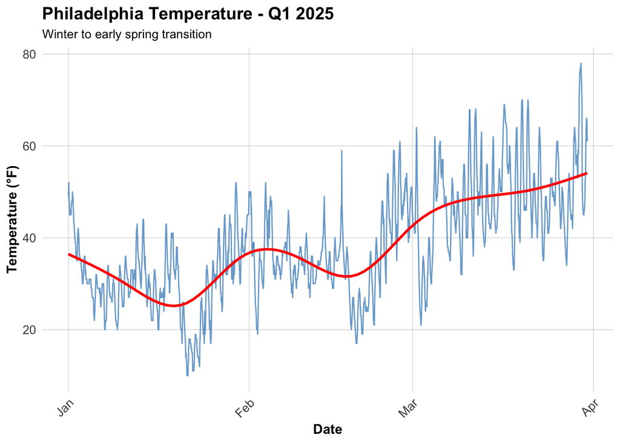

```r
ggplot(weather_complete, aes(x = interval60, y = Temperature)) +
  geom_line(color = "#3182bd", alpha = 0.7) +
  geom_smooth(se = FALSE, color = "red") +
  labs(
    title = "Philadelphia Temperature - Q1 2025",
    subtitle = "Winter to early spring transition",
    x = "Date",
    y = "Temperature (°F)"
  ) +
  plotTheme
```

# CREATE SPACE-TIME PANEL

## Aggregate Trips to Station-Hour Level

```r
# Count trips by station-hour
trips_panel <- indego_census %>%
  group_by(interval60, start_station, start_lat, start_lon,
           Med_Inc, Percent_Taking_Transit, Percent_White, Total_Pop) %>%
  summarize(Trip_Count = n()) %>%
  ungroup()

# How many station-hour observations?
nrow(trips_panel)
```

```
[1] 116718
```

```r
# How many unique stations?
length(unique(trips_panel$start_station))
```

```
[1] 245
```

```r
# How many unique hours?
length(unique(trips_panel$interval60))
```

```
[1] 2150
```

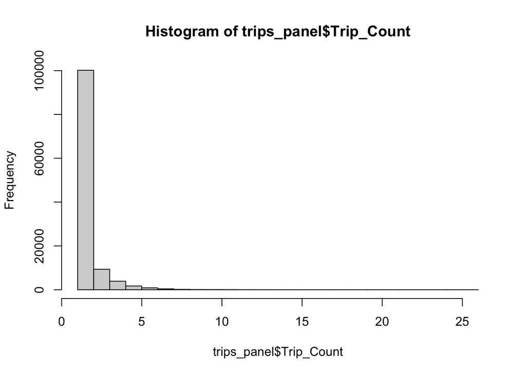

```r
hist(trips_panel$Trip_Count)
```

## Create Complete Panel Structure

Not every station has trips every hour. We need a **complete panel** where every station-hour combination exists (even if Trip_Count = 0).

```r
# Calculate expected panel size
n_stations <- length(unique(trips_panel$start_station))
n_hours <- length(unique(trips_panel$interval60))
expected_rows <- n_stations * n_hours

cat("Expected panel rows:", format(expected_rows, big.mark = ","), "\n")
```

```
Expected panel rows: 526,750
```

```r
cat("Current rows:", format(nrow(trips_panel), big.mark = ","), "\n")
```

```
Current rows: 116,718
```

```r
cat("Missing rows:", format(expected_rows - nrow(trips_panel), big.mark = ","), "\n")
```

```
Missing rows: 410,032
```

```r
# Create complete panel
study_panel <- expand_grid(
  interval60 = unique(trips_panel$interval60),
  start_station = unique(trips_panel$start_station)
) %>%
  # Join trip counts
  left_join(trips_panel %>%
              select(interval60, start_station, Trip_Count),
            by = c("interval60", "start_station")) %>%
  # Replace NA trip counts with 0
  mutate(Trip_Count = replace_na(Trip_Count, 0))

glimpse(study_panel)
```

```
Rows: 526,750
Columns: 3
$ interval60    <dttm> 2025-01-01, 2025-01-01, 2025-01-01, 2025-01-01, 2025-01…
$ start_station <dbl> 3005, 3007, 3015, 3021, 3026, 3028, 3029, 3030, 3032, 30…
$ Trip_Count    <int> 6, 1, 4, 1, 2, 1, 2, 1, 1, 1, 1, 1, 1, 1, 2, 3, 1, 1, 3,…
```

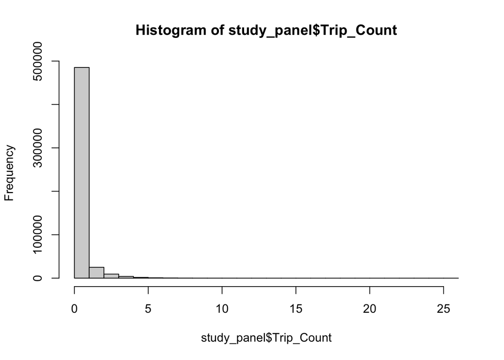

```r
hist(study_panel$Trip_Count)
```

```r
# Fill in station attributes (they're the same for all hours)
station_attributes <- trips_panel %>%
  group_by(start_station) %>%
  summarize(
    start_lat = first(start_lat),
    start_lon = first(start_lon),
    Med_Inc = first(Med_Inc),
    Percent_Taking_Transit = first(Percent_Taking_Transit),
    Percent_White = first(Percent_White),
    Total_Pop = first(Total_Pop)
  )

glimpse(station_attributes)
```

```
Rows: 245
Columns: 7
$ start_station          <dbl> 3005, 3006, 3007, 3008, 3009, 3010, 3012, 3014,…
$ start_lat              <dbl> 39.94733, 39.95220, 39.94517, 39.98081, 39.9557…
$ start_lon              <dbl> -75.14403, -75.20311, -75.15993, -75.15067, -75…
$ Med_Inc                <dbl> 144922, 21064, 58557, 22244, 37674, 88583, 1385…
$ Percent_Taking_Transit <dbl> 11.742827, 9.418565, 11.401515, 27.430556, 10.8…
$ Percent_White          <dbl> 86.29640, 46.88109, 62.85341, 39.65227, 60.2169…
$ Total_Pop              <dbl> 3583, 6156, 4598, 5349, 7375, 3134, 3643, 3914,…
```

```r
study_panel <- study_panel %>%
  left_join(station_attributes, by = "start_station")

glimpse(study_panel)
```

```
Rows: 526,750
Columns: 9
$ interval60             <dttm> 2025-01-01, 2025-01-01, 2025-01-01, 2025-01-01…
$ start_station          <dbl> 3005, 3007, 3015, 3021, 3026, 3028, 3029, 3030,…
$ Trip_Count             <int> 6, 1, 4, 1, 2, 1, 2, 1, 1, 1, 1, 1, 1, 1, 2, 3,…
$ start_lat              <dbl> 39.94733, 39.94517, 39.94735, 39.95390, 39.9418…
$ start_lon              <dbl> -75.14403, -75.15993, -75.14886, -75.16902, -75…
$ Med_Inc                <dbl> 144922, 58557, 144922, 90980, 144922, 146071, 2…
$ Percent_Taking_Transit <dbl> 11.742827, 11.401515, 11.742827, 17.800289, 11.…
$ Percent_White          <dbl> 86.29640, 62.85341, 86.29640, 79.26518, 86.2964…
$ Total_Pop              <dbl> 3583, 4598, 3583, 3130, 3583, 2428, 6267, 3300,…
```

```r
# Verify we have complete panel
cat("Complete panel rows:", format(nrow(study_panel), big.mark = ","), "\n")
```

```
Complete panel rows: 526,750
```

## Add Time Features

```r
study_panel <- study_panel %>%
  mutate(
    week = week(interval60),
    month = month(interval60, label = TRUE),
    dotw = wday(interval60, label = TRUE),
    hour = hour(interval60),
    date = as.Date(interval60),
    weekend = ifelse(dotw %in% c("Sat", "Sun"), 1, 0),
    rush_hour = ifelse(hour %in% c(7, 8, 9, 16, 17, 18), 1, 0)
  )

glimpse(study_panel)
```

```
Rows: 526,750
Columns: 16
$ interval60             <dttm> 2025-01-01, 2025-01-01, 2025-01-01, 2025-01-01…
$ start_station          <dbl> 3005, 3007, 3015, 3021, 3026, 3028, 3029, 3030,…
$ Trip_Count             <int> 6, 1, 4, 1, 2, 1, 2, 1, 1, 1, 1, 1, 1, 1, 2, 3,…
$ start_lat              <dbl> 39.94733, 39.94517, 39.94735, 39.95390, 39.9418…
$ start_lon              <dbl> -75.14403, -75.15993, -75.14886, -75.16902, -75…
$ Med_Inc                <dbl> 144922, 58557, 144922, 90980, 144922, 146071, 2…
$ Percent_Taking_Transit <dbl> 11.742827, 11.401515, 11.742827, 17.800289, 11.…
$ Percent_White          <dbl> 86.29640, 62.85341, 86.29640, 79.26518, 86.2964…
$ Total_Pop              <dbl> 3583, 4598, 3583, 3130, 3583, 2428, 6267, 3300,…
$ week                   <dbl> 1, 1, 1, 1, 1, 1, 1, 1, 1, 1, 1, 1, 1, 1, 1, 1,…
$ month                  <ord> Jan, Jan, Jan, Jan, Jan, Jan, Jan, Jan, Jan, Ja…
$ dotw                   <ord> Wed, Wed, Wed, Wed, Wed, Wed, Wed, Wed, Wed, We…
$ hour                   <int> 0, 0, 0, 0, 0, 0, 0, 0, 0, 0, 0, 0, 0, 0, 0, 0,…
$ date                   <date> 2025-01-01, 2025-01-01, 2025-01-01, 2025-01-01…
$ weekend                <dbl> 0, 0, 0, 0, 0, 0, 0, 0, 0, 0, 0, 0, 0, 0, 0, 0,…
$ rush_hour              <dbl> 0, 0, 0, 0, 0, 0, 0, 0, 0, 0, 0, 0, 0, 0, 0, 0,…
```

## Join Weather Data

```r
study_panel <- study_panel %>%
  left_join(weather_complete, by = "interval60")

glimpse(study_panel)
```

```
Rows: 526,750
Columns: 19
$ interval60             <dttm> 2025-01-01, 2025-01-01, 2025-01-01, 2025-01-01…
$ start_station          <dbl> 3005, 3007, 3015, 3021, 3026, 3028, 3029, 3030,…
$ Trip_Count             <int> 6, 1, 4, 1, 2, 1, 2, 1, 1, 1, 1, 1, 1, 1, 2, 3,…
$ start_lat              <dbl> 39.94733, 39.94517, 39.94735, 39.95390, 39.9418…
$ start_lon              <dbl> -75.14403, -75.15993, -75.14886, -75.16902, -75…
$ Med_Inc                <dbl> 144922, 58557, 144922, 90980, 144922, 146071, 2…
$ Percent_Taking_Transit <dbl> 11.742827, 11.401515, 11.742827, 17.800289, 11.…
$ Percent_White          <dbl> 86.29640, 62.85341, 86.29640, 79.26518, 86.2964…
$ Total_Pop              <dbl> 3583, 4598, 3583, 3130, 3583, 2428, 6267, 3300,…
$ week                   <dbl> 1, 1, 1, 1, 1, 1, 1, 1, 1, 1, 1, 1, 1, 1, 1, 1,…
$ month                  <ord> Jan, Jan, Jan, Jan, Jan, Jan, Jan, Jan, Jan, Ja…
$ dotw                   <ord> Wed, Wed, Wed, Wed, Wed, Wed, Wed, Wed, Wed, We…
$ hour                   <int> 0, 0, 0, 0, 0, 0, 0, 0, 0, 0, 0, 0, 0, 0, 0, 0,…
$ date                   <date> 2025-01-01, 2025-01-01, 2025-01-01, 2025-01-01…
$ weekend                <dbl> 0, 0, 0, 0, 0, 0, 0, 0, 0, 0, 0, 0, 0, 0, 0, 0,…
$ rush_hour              <dbl> 0, 0, 0, 0, 0, 0, 0, 0, 0, 0, 0, 0, 0, 0, 0, 0,…
$ Temperature            <dbl> 50, 50, 50, 50, 50, 50, 50, 50, 50, 50, 50, 50,…
$ Precipitation          <dbl> 0.06, 0.06, 0.06, 0.06, 0.06, 0.06, 0.06, 0.06,…
$ Wind_Speed             <dbl> 9, 9, 9, 9, 9, 9, 9, 9, 9, 9, 9, 9, 9, 9, 9, 9,…
```

```r
# Check for missing values
summary(study_panel %>% select(Trip_Count, Temperature, Precipitation))
```

```
   Trip_Count       Temperature    Precipitation
 Min.   : 0.0000   Min.   :10.00   Min.   :0.000
 1st Qu.: 0.0000   1st Qu.:30.00   1st Qu.:0.000
 Median : 0.0000   Median :37.00   Median :0.000
 Mean   : 0.3585   Mean   :38.39   Mean   :0.001
 3rd Qu.: 0.0000   3rd Qu.:46.00   3rd Qu.:0.000
 Max.   :26.0000   Max.   :78.00   Max.   :0.280
                   NA's   :5880    NA's   :5880
```

# CREATE TEMPORAL LAG VARIABLES

The key innovation for space-time prediction: **past demand predicts future demand**.

## Why Temporal Lags?

If there were 15 bike trips from Station A at 8:00 AM, there will probably be ~15 trips at 9:00 AM. We can use this temporal persistence to improve predictions.

**Note:** We still can’t use spatial lags in prediction. Temporal lags are different because time moves in one direction - past predicts the future, but the future does not predict the past. Spatial lags are non-directional and create circular prediction logic.

Temporal lags: good Spatial lags: bad!

```r
# Sort by station and time
study_panel <- study_panel %>%
  arrange(start_station, interval60)

# Create lag variables WITHIN each station
study_panel <- study_panel %>%
  group_by(start_station) %>%
  mutate(
    lag1Hour = lag(Trip_Count, 1),
    lag2Hours = lag(Trip_Count, 2),
    lag3Hours = lag(Trip_Count, 3),
    lag12Hours = lag(Trip_Count, 12),
    lag1day = lag(Trip_Count, 24)
  ) %>%
  ungroup()

# Remove rows with NA lags (first 24 hours for each station)
study_panel_complete <- study_panel %>%
  filter(!is.na(lag1day))

cat("Rows after removing NA lags:", format(nrow(study_panel_complete), big.mark = ","), "\n")
```

```
Rows after removing NA lags: 520,870
```

## Visualize Lag Correlations

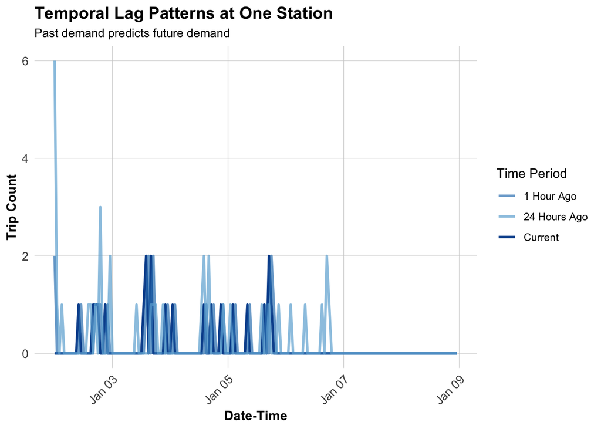

```r
# Sample one station to visualize
example_station <- study_panel_complete %>%
  filter(start_station == first(start_station)) %>%
  head(168)  # One week

# Plot actual vs lagged demand
ggplot(example_station, aes(x = interval60)) +
  geom_line(aes(y = Trip_Count, color = "Current"), linewidth = 1) +
  geom_line(aes(y = lag1Hour, color = "1 Hour Ago"), linewidth = 1, alpha = 0.7) +
  geom_line(aes(y = lag1day, color = "24 Hours Ago"), linewidth = 1, alpha = 0.7) +
  scale_color_manual(values = c(
    "Current" = "#08519c",
    "1 Hour Ago" = "#3182bd",
    "24 Hours Ago" = "#6baed6"
  )) +
  labs(
    title = "Temporal Lag Patterns at One Station",
    subtitle = "Past demand predicts future demand",
    x = "Date-Time",
    y = "Trip Count",
    color = "Time Period"
  ) +
  plotTheme
```

# TEMPORAL TRAIN/TEST SPLIT

**CRITICAL:** We must train on PAST data and test on FUTURE data!

## Why Temporal Validation Matters

In real operations, at 6:00 AM on March 15, we need to predict demand for March 15-31. We have data from Jan 1 - March 14, but NOT from March 15-31 (it hasn’t happened yet!).

**Wrong approach:** Train on weeks 10-13, test on weeks 1-9 (predicting past from future!)

**Correct approach:** Train on weeks 1-9, test on weeks 10-13 (predicting future from past)

```r
# Split by week
# Q1 has weeks 1-13 (Jan-Mar)
# Train on weeks 1-9 (Jan 1 - early March)
# Test on weeks 10-13 (rest of March)

# Which stations have trips in BOTH early and late periods?
early_stations <- study_panel_complete %>%
  filter(week < 10) %>%
  filter(Trip_Count > 0) %>%
  distinct(start_station) %>%
  pull(start_station)

late_stations <- study_panel_complete %>%
  filter(week >= 10) %>%
  filter(Trip_Count > 0) %>%
  distinct(start_station) %>%
  pull(start_station)

# Keep only stations that appear in BOTH periods
common_stations <- intersect(early_stations, late_stations)


# Filter panel to only common stations
study_panel_complete <- study_panel_complete %>%
  filter(start_station %in% common_stations)

# NOW create train/test split
train <- study_panel_complete %>%
  filter(week < 10)

test <- study_panel_complete %>%
  filter(week >= 10)

cat("Training observations:", format(nrow(train), big.mark = ","), "\n")
```

```
Training observations: 352,240
```

```r
cat("Testing observations:", format(nrow(test), big.mark = ","), "\n")
```

```
Testing observations: 153,748
```

```r
cat("Training date range:", min(train$date), "to", max(train$date), "\n")
```

```
Training date range: 20090 to 20151
```

```r
cat("Testing date range:", min(test$date), "to", max(test$date), "\n")
```

```
Testing date range: 20152 to 20178
```

#BUILD PREDICTIVE MODELS

We’ll build 5 models with increasing complexity to see what improves predictions.

## Model 1: Baseline (Time + Weather)

```r
# Create day of week factor with treatment (dummy) coding
train <- train %>%
  mutate(dotw_simple = factor(dotw, levels = c("Mon", "Tue", "Wed", "Thu", "Fri", "Sat", "Sun")))

# Set contrasts to treatment coding (dummy variables)
contrasts(train$dotw_simple) <- contr.treatment(7)

# Now run the model
model1 <- lm(
  Trip_Count ~ as.factor(hour) + dotw_simple + Temperature + Precipitation,
  data = train
)

summary(model1)
```

```
Call:
lm(formula = Trip_Count ~ as.factor(hour) + dotw_simple + Temperature +
    Precipitation, data = train)

Residuals:
    Min      1Q  Median      3Q     Max
-0.9505 -0.4005 -0.1795  0.0221 18.5359

Coefficients:
                    Estimate Std. Error t value             Pr(>|t|)
(Intercept)       -0.1865881  0.0087166 -21.406 < 0.0000000000000002 ***
as.factor(hour)1  -0.0254861  0.0087583  -2.910              0.00362 **
as.factor(hour)2  -0.0363902  0.0088009  -4.135  0.00003553166352763 ***
as.factor(hour)3  -0.0525056  0.0087645  -5.991  0.00000000209104740 ***
as.factor(hour)4  -0.0364554  0.0087381  -4.172  0.00003019750974030 ***
as.factor(hour)5   0.0230901  0.0087069   2.652              0.00800 **
as.factor(hour)6   0.1744174  0.0087150  20.014 < 0.0000000000000002 ***
as.factor(hour)7   0.3241655  0.0087182  37.183 < 0.0000000000000002 ***
as.factor(hour)8   0.5499211  0.0087229  63.044 < 0.0000000000000002 ***
as.factor(hour)9   0.3904427  0.0087209  44.771 < 0.0000000000000002 ***
as.factor(hour)10  0.2810826  0.0087269  32.209 < 0.0000000000000002 ***
as.factor(hour)11  0.2964398  0.0087321  33.948 < 0.0000000000000002 ***
as.factor(hour)12  0.3676829  0.0087199  42.166 < 0.0000000000000002 ***
as.factor(hour)13  0.3494810  0.0086973  40.183 < 0.0000000000000002 ***
as.factor(hour)14  0.3519969  0.0086887  40.512 < 0.0000000000000002 ***
as.factor(hour)15  0.4082093  0.0086904  46.972 < 0.0000000000000002 ***
as.factor(hour)16  0.4901333  0.0086951  56.369 < 0.0000000000000002 ***
as.factor(hour)17  0.6148350  0.0087059  70.623 < 0.0000000000000002 ***
as.factor(hour)18  0.4245184  0.0087149  48.712 < 0.0000000000000002 ***
as.factor(hour)19  0.2709915  0.0087215  31.072 < 0.0000000000000002 ***
as.factor(hour)20  0.1498838  0.0087168  17.195 < 0.0000000000000002 ***
as.factor(hour)21  0.0883229  0.0087071  10.144 < 0.0000000000000002 ***
as.factor(hour)22  0.0688853  0.0086978   7.920  0.00000000000000239 ***
as.factor(hour)23  0.0416985  0.0086883   4.799  0.00000159201720578 ***
dotw_simple2       0.0534158  0.0046920  11.384 < 0.0000000000000002 ***
dotw_simple3       0.0591069  0.0048452  12.199 < 0.0000000000000002 ***
dotw_simple4       0.0329187  0.0046852   7.026  0.00000000000212695 ***
dotw_simple5       0.0432028  0.0046773   9.237 < 0.0000000000000002 ***
dotw_simple6      -0.0654894  0.0046757 -14.006 < 0.0000000000000002 ***
dotw_simple7      -0.0629789  0.0047034 -13.390 < 0.0000000000000002 ***
Temperature        0.0079845  0.0001544  51.702 < 0.0000000000000002 ***
Precipitation     -2.5026380  0.1914911 -13.069 < 0.0000000000000002 ***
---
Signif. codes:  0 '***' 0.001 '**' 0.01 '*' 0.05 '.' 0.1 ' ' 1

Residual standard error: 0.746 on 352208 degrees of freedom
Multiple R-squared:  0.07881,   Adjusted R-squared:  0.07873
F-statistic:   972 on 31 and 352208 DF,  p-value: < 0.00000000000000022
```

The model uses Monday as the baseline. Each coefficient represents the difference in expected trips per station-hour compared to Monday - dow_simple2 = Tuesday..

**Weekday Pattern (Tue-Fri):**

**Weekend Pattern (Sat-Sun):**

**Hourly Interpretation**

Isn’t this fun!

## Model 2: Add Temporal Lags

```r
model2 <- lm(
  Trip_Count ~ as.factor(hour) + dotw_simple + Temperature + Precipitation +
    lag1Hour + lag3Hours + lag1day,
  data = train
)

summary(model2)
```

```
Call:
lm(formula = Trip_Count ~ as.factor(hour) + dotw_simple + Temperature +
    Precipitation + lag1Hour + lag3Hours + lag1day, data = train)

Residuals:
    Min      1Q  Median      3Q     Max
-4.8168 -0.2847 -0.1032  0.0169 17.7976

Coefficients:
                    Estimate Std. Error t value             Pr(>|t|)
(Intercept)       -0.0981452  0.0079807 -12.298 < 0.0000000000000002 ***
as.factor(hour)1  -0.0073089  0.0080114  -0.912              0.36161
as.factor(hour)2  -0.0056704  0.0080509  -0.704              0.48124
as.factor(hour)3  -0.0098486  0.0080187  -1.228              0.21937
as.factor(hour)4   0.0073214  0.0079952   0.916              0.35981
as.factor(hour)5   0.0541355  0.0079676   6.794  0.00000000001088671 ***
as.factor(hour)6   0.1598589  0.0079803  20.032 < 0.0000000000000002 ***
as.factor(hour)7   0.2402233  0.0079951  30.046 < 0.0000000000000002 ***
as.factor(hour)8   0.3755384  0.0080279  46.779 < 0.0000000000000002 ***
as.factor(hour)9   0.1807415  0.0080254  22.521 < 0.0000000000000002 ***
as.factor(hour)10  0.1188012  0.0080068  14.838 < 0.0000000000000002 ***
as.factor(hour)11  0.1347784  0.0080231  16.799 < 0.0000000000000002 ***
as.factor(hour)12  0.2042401  0.0080027  25.521 < 0.0000000000000002 ***
as.factor(hour)13  0.1863749  0.0079803  23.354 < 0.0000000000000002 ***
as.factor(hour)14  0.1933502  0.0079711  24.256 < 0.0000000000000002 ***
as.factor(hour)15  0.2303877  0.0079791  28.874 < 0.0000000000000002 ***
as.factor(hour)16  0.2798055  0.0079958  34.994 < 0.0000000000000002 ***
as.factor(hour)17  0.3592389  0.0080276  44.750 < 0.0000000000000002 ***
as.factor(hour)18  0.1723963  0.0080312  21.466 < 0.0000000000000002 ***
as.factor(hour)19  0.0896528  0.0080112  11.191 < 0.0000000000000002 ***
as.factor(hour)20  0.0154708  0.0080102   1.931              0.05344 .
as.factor(hour)21  0.0133420  0.0079787   1.672              0.09449 .
as.factor(hour)22  0.0257497  0.0079603   3.235              0.00122 **
as.factor(hour)23  0.0204881  0.0079476   2.578              0.00994 **
dotw_simple2       0.0203302  0.0042937   4.735  0.00000219283951014 ***
dotw_simple3       0.0107868  0.0044368   2.431              0.01505 *
dotw_simple4      -0.0016960  0.0042891  -0.395              0.69254
dotw_simple5       0.0111818  0.0042805   2.612              0.00900 **
dotw_simple6      -0.0723041  0.0042858 -16.871 < 0.0000000000000002 ***
dotw_simple7      -0.0433412  0.0043053 -10.067 < 0.0000000000000002 ***
Temperature        0.0036893  0.0001423  25.920 < 0.0000000000000002 ***
Precipitation     -1.3733842  0.1752334  -7.837  0.00000000000000461 ***
lag1Hour           0.2285048  0.0016338 139.865 < 0.0000000000000002 ***
lag3Hours          0.0974819  0.0016053  60.726 < 0.0000000000000002 ***
lag1day            0.2350577  0.0016168 145.387 < 0.0000000000000002 ***
---
Signif. codes:  0 '***' 0.001 '**' 0.01 '*' 0.05 '.' 0.1 ' ' 1

Residual standard error: 0.6823 on 352205 degrees of freedom
Multiple R-squared:  0.2293,    Adjusted R-squared:  0.2292
F-statistic:  3082 on 34 and 352205 DF,  p-value: < 0.00000000000000022
```

**Question:** Did adding lags improve R²? Why or why not?

## Model 3: Add Demographics

```r
model3 <- lm(
  Trip_Count ~ as.factor(hour) + dotw_simple + Temperature + Precipitation +
    lag1Hour + lag3Hours + lag1day +
    Med_Inc + Percent_Taking_Transit + Percent_White,
  data = train
)

summary(model3)
```

```
Call:
lm(formula = Trip_Count ~ as.factor(hour) + dotw_simple + Temperature +
    Precipitation + lag1Hour + lag3Hours + lag1day + Med_Inc +
    Percent_Taking_Transit + Percent_White, data = train)

Residuals:
    Min      1Q  Median      3Q     Max
-4.6781 -0.2928 -0.1040  0.0416 17.7669

Coefficients:
                             Estimate     Std. Error t value
(Intercept)            -0.19313819262  0.00923311923 -20.918
as.factor(hour)1       -0.00799461927  0.00798751053  -1.001
as.factor(hour)2       -0.00692313434  0.00802697156  -0.862
as.factor(hour)3       -0.01170272248  0.00799487410  -1.464
as.factor(hour)4        0.00532779538  0.00797145169   0.668
as.factor(hour)5        0.05247025337  0.00794386290   6.605
as.factor(hour)6        0.15961351650  0.00795646144  20.061
as.factor(hour)7        0.24230559043  0.00797137108  30.397
as.factor(hour)8        0.38091625076  0.00800478190  47.586
as.factor(hour)9        0.18794185116  0.00800303366  23.484
as.factor(hour)10       0.12517589185  0.00798410205  15.678
as.factor(hour)11       0.14226414630  0.00800084164  17.781
as.factor(hour)12       0.21096634554  0.00798016494  26.436
as.factor(hour)13       0.19245141624  0.00795755375  24.185
as.factor(hour)14       0.19928012231  0.00794838591  25.072
as.factor(hour)15       0.23726523874  0.00795670102  29.820
as.factor(hour)16       0.28770940221  0.00797379314  36.082
as.factor(hour)17       0.36865408137  0.00800627902  46.046
as.factor(hour)18       0.18193513668  0.00800987884  22.714
as.factor(hour)19       0.09728716206  0.00798900814  12.178
as.factor(hour)20       0.02225418222  0.00798764893   2.786
as.factor(hour)21       0.01731586919  0.00795540485   2.177
as.factor(hour)22       0.02800711868  0.00793668256   3.529
as.factor(hour)23       0.02147968094  0.00792394388   2.711
dotw_simple2            0.02163608068  0.00428100242   5.054
dotw_simple3            0.01263479071  0.00442375706   2.856
dotw_simple4           -0.00043701988  0.00427636580  -0.102
dotw_simple5            0.01241705386  0.00426785841   2.909
dotw_simple6           -0.07235969603  0.00427299524 -16.934
```

[output cut: 39 more lines]

```
dotw_simple7           < 0.0000000000000002 ***
Temperature            < 0.0000000000000002 ***
Precipitation          0.000000000000000359 ***
lag1Hour               < 0.0000000000000002 ***
lag3Hours              < 0.0000000000000002 ***
lag1day                < 0.0000000000000002 ***
Med_Inc                0.000000006864124093 ***
Percent_Taking_Transit 0.000000000581867100 ***
Percent_White          < 0.0000000000000002 ***
---
Signif. codes:  0 '***' 0.001 '**' 0.01 '*' 0.05 '.' 0.1 ' ' 1

Residual standard error: 0.6803 on 352202 degrees of freedom
Multiple R-squared:  0.2339,    Adjusted R-squared:  0.2338
F-statistic:  2906 on 37 and 352202 DF,  p-value: < 0.00000000000000022
```

## Model 4: Add Station Fixed Effects

```r
model4 <- lm(
  Trip_Count ~ as.factor(hour) + dotw_simple + Temperature + Precipitation +
    lag1Hour + lag3Hours + lag1day +
    Med_Inc + Percent_Taking_Transit + Percent_White +
    as.factor(start_station),
  data = train
)

# Summary too long with all station dummies, just show key metrics
cat("Model 4 R-squared:", summary(model4)$r.squared, "\n")
```

```
Model 4 R-squared: 0.2622708
```

```r
cat("Model 4 Adj R-squared:", summary(model4)$adj.r.squared, "\n")
```

```
Model 4 Adj R-squared: 0.2617028
```

**What do station fixed effects capture?** Baseline differences in demand across stations (some are just busier than others!).

## Model 5: Add Rush Hour Interaction

```r
model5 <- lm(
  Trip_Count ~ as.factor(hour) + dotw_simple + Temperature + Precipitation +
    lag1Hour + lag3Hours + lag1day + rush_hour + as.factor(month) +
    Med_Inc + Percent_Taking_Transit + Percent_White +
    as.factor(start_station) +
    rush_hour * weekend,  # Rush hour effects different on weekends
  data = train
)

cat("Model 5 R-squared:", summary(model5)$r.squared, "\n")
```

```
Model 5 R-squared: 0.2671713
```

```r
cat("Model 5 Adj R-squared:", summary(model5)$adj.r.squared, "\n")
```

```
Model 5 Adj R-squared: 0.2666008
```

# MODEL EVALUATION

## Calculate Predictions and MAE

```r
# Get predictions on test set

# Create day of week factor with treatment (dummy) coding
test <- test %>%
  mutate(dotw_simple = factor(dotw, levels = c("Mon", "Tue", "Wed", "Thu", "Fri", "Sat", "Sun")))

# Set contrasts to treatment coding (dummy variables)
contrasts(test$dotw_simple) <- contr.treatment(7)

test <- test %>%
  mutate(
    pred1 = predict(model1, newdata = test),
    pred2 = predict(model2, newdata = test),
    pred3 = predict(model3, newdata = test),
    pred4 = predict(model4, newdata = test),
    pred5 = predict(model5, newdata = test)
  )

# Calculate MAE for each model
mae_results <- data.frame(
  Model = c(
    "1. Time + Weather",
    "2. + Temporal Lags",
    "3. + Demographics",
    "4. + Station FE",
    "5. + Rush Hour Interaction"
  ),
  MAE = c(
    mean(abs(test$Trip_Count - test$pred1), na.rm = TRUE),
    mean(abs(test$Trip_Count - test$pred2), na.rm = TRUE),
    mean(abs(test$Trip_Count - test$pred3), na.rm = TRUE),
    mean(abs(test$Trip_Count - test$pred4), na.rm = TRUE),
    mean(abs(test$Trip_Count - test$pred5), na.rm = TRUE)
  )
)

kable(mae_results,
      digits = 2,
      caption = "Mean Absolute Error by Model (Test Set)",
      col.names = c("Model", "MAE (trips)")) %>%
  kable_styling(bootstrap_options = c("striped", "hover"))
```

Mean Absolute Error by Model (Test Set)

| Model | MAE (trips) |
| --- | --- |
| 1. Time + Weather | 0.62 |
| 2. + Temporal Lags | 0.54 |
| 3. + Demographics | 0.53 |
| 4. + Station FE | 0.53 |
| 5. + Rush Hour Interaction | 0.53 |

## Visualize Model Comparison

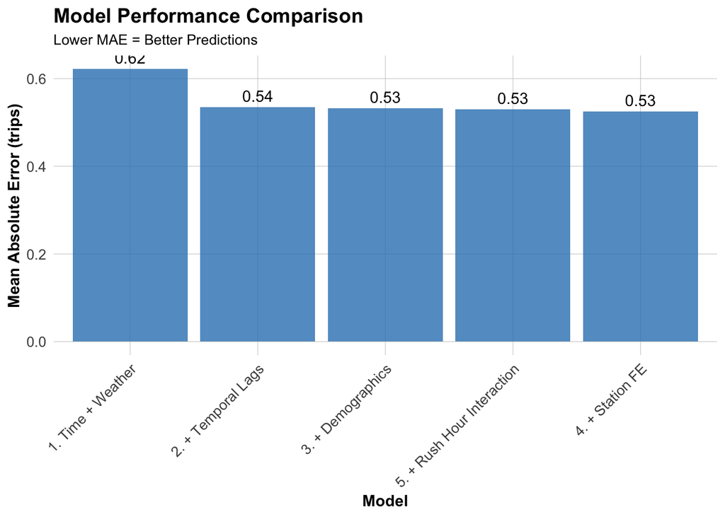

```r
ggplot(mae_results, aes(x = reorder(Model, -MAE), y = MAE)) +
  geom_col(fill = "#3182bd", alpha = 0.8) +
  geom_text(aes(label = round(MAE, 2)), vjust = -0.5) +
  labs(
    title = "Model Performance Comparison",
    subtitle = "Lower MAE = Better Predictions",
    x = "Model",
    y = "Mean Absolute Error (trips)"
  ) +
  plotTheme +
  theme(axis.text.x = element_text(angle = 45, hjust = 1))
```

**Question:** Which features gave us the biggest improvement?

# SPACE-TIME ERROR ANALYSIS

## Observed vs. Predicted

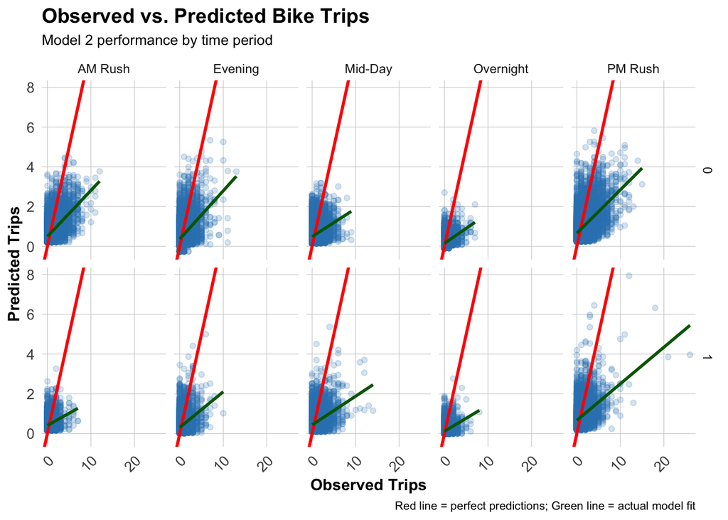

```r
test <- test %>%
  mutate(
    error = Trip_Count - pred2,
    abs_error = abs(error),
    time_of_day = case_when(
      hour < 7 ~ "Overnight",
      hour >= 7 & hour < 10 ~ "AM Rush",
      hour >= 10 & hour < 15 ~ "Mid-Day",
      hour >= 15 & hour <= 18 ~ "PM Rush",
      hour > 18 ~ "Evening"
    )
  )

# Scatter plot by time and day type
ggplot(test, aes(x = Trip_Count, y = pred2)) +
  geom_point(alpha = 0.2, color = "#3182bd") +
  geom_abline(slope = 1, intercept = 0, color = "red", linewidth = 1) +
  geom_smooth(method = "lm", se = FALSE, color = "darkgreen") +
  facet_grid(weekend ~ time_of_day) +
  labs(
    title = "Observed vs. Predicted Bike Trips",
    subtitle = "Model 2 performance by time period",
    x = "Observed Trips",
    y = "Predicted Trips",
    caption = "Red line = perfect predictions; Green line = actual model fit"
  ) +
  plotTheme
```

**Question:** Where is the model performing well? Where is it struggling?

## Spatial Error Patterns

Are prediction errors clustered in certain parts of Philadelphia?

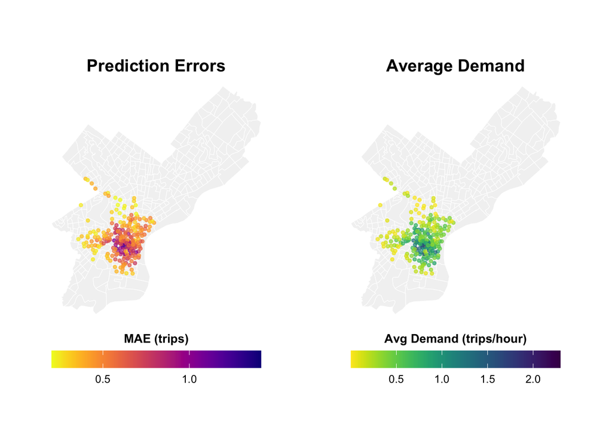

```r
# Calculate MAE by station
station_errors <- test %>%
  group_by(start_station, start_lat, start_lon) %>%
  summarize(
    MAE = mean(abs_error, na.rm = TRUE),
    avg_demand = mean(Trip_Count, na.rm = TRUE),
    .groups = "drop"
  ) %>%
  filter(!is.na(start_lat), !is.na(start_lon))

## Create Two Maps Side-by-Side with Proper Legends (sorry these maps are ugly)

# Calculate station errors
station_errors <- test %>%
  filter(!is.na(pred2)) %>%
  group_by(start_station, start_lat, start_lon) %>%
  summarize(
    MAE = mean(abs(Trip_Count - pred2), na.rm = TRUE),
    avg_demand = mean(Trip_Count, na.rm = TRUE),
    .groups = "drop"
  ) %>%
  filter(!is.na(start_lat), !is.na(start_lon))

# Map 1: Prediction Errors
p1 <- ggplot() +
  geom_sf(data = philly_census, fill = "grey95", color = "white", size = 0.1) +
  geom_point(
    data = station_errors,
    aes(x = start_lon, y = start_lat, color = MAE),
    size = 1, #so you can see
    alpha = 0.7
  ) +
  scale_color_viridis(
    option = "plasma",
    name = "MAE (trips)",
    direction = -1,
    breaks = c(0.5, 1.0, 1.5),
    labels = c("0.5", "1.0", "1.5")
  ) +
  labs(title = "Prediction Errors") +
  mapTheme +
  theme(
    legend.position = "bottom",
    legend.title = element_text(size = 10, face = "bold"),
    legend.text = element_text(size = 9),
    plot.title = element_text(size = 14, face = "bold", hjust = 0.5)
  ) +
  guides(color = guide_colorbar(
    barwidth = 12,
    barheight = 1,
    title.position = "top",
    title.hjust = 0.5
  ))

# Map 2: Average Demand
p2 <- ggplot() +
  geom_sf(data = philly_census, fill = "grey95", color = "white", size = 0.1) +
  geom_point(
    data = station_errors,
    aes(x = start_lon, y = start_lat, color = avg_demand),
    size = 1, #so you can see
    alpha = 0.7
  ) +
  scale_color_viridis(
    option = "viridis",
    name = "Avg Demand (trips/hour)",
    direction = -1,
    breaks = c(0.5, 1.0, 1.5, 2.0, 2.5),
    labels = c("0.5", "1.0", "1.5", "2.0", "2.5")
  ) +
  labs(title = "Average Demand") +
  mapTheme +
  theme(
    legend.position = "bottom",
    legend.title = element_text(size = 10, face = "bold"),
    legend.text = element_text(size = 9),
    plot.title = element_text(size = 14, face = "bold", hjust = 0.5)
  ) +
  guides(color = guide_colorbar(
    barwidth = 12,
    barheight = 1,
    title.position = "top",
    title.hjust = 0.5
  ))

# Combine
(p1 | p2)
```

**Question:** Do you see spatial clustering of errors? What neighborhoods have high errors?

## Temporal Error Patterns

When are we most wrong?

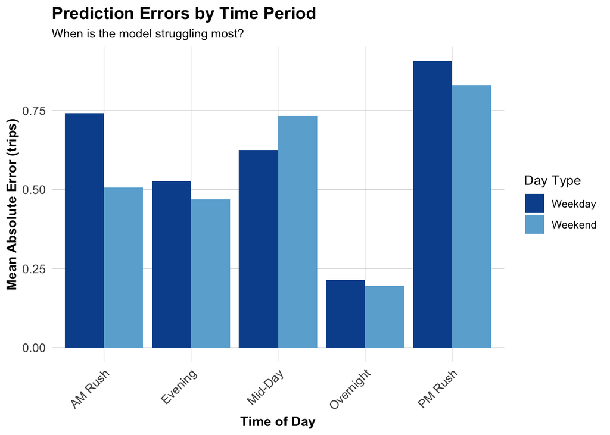

```r
# MAE by time of day and day type
temporal_errors <- test %>%
  group_by(time_of_day, weekend) %>%
  summarize(
    MAE = mean(abs_error, na.rm = TRUE),
    .groups = "drop"
  ) %>%
  mutate(day_type = ifelse(weekend == 1, "Weekend", "Weekday"))

ggplot(temporal_errors, aes(x = time_of_day, y = MAE, fill = day_type)) +
  geom_col(position = "dodge") +
  scale_fill_manual(values = c("Weekday" = "#08519c", "Weekend" = "#6baed6")) +
  labs(
    title = "Prediction Errors by Time Period",
    subtitle = "When is the model struggling most?",
    x = "Time of Day",
    y = "Mean Absolute Error (trips)",
    fill = "Day Type"
  ) +
  plotTheme +
  theme(axis.text.x = element_text(angle = 45, hjust = 1))
```

## Errors and Demographics

Are prediction errors related to neighborhood characteristics?

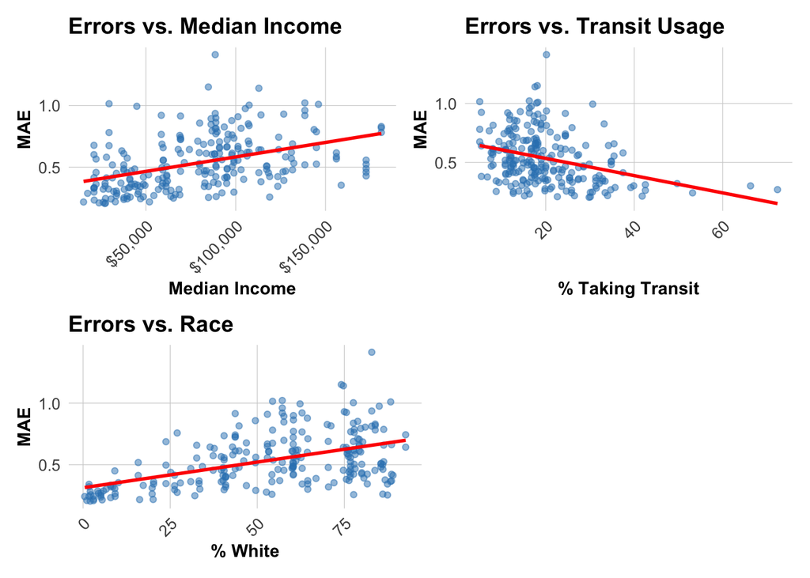

```r
# Join demographic data to station errors
station_errors_demo <- station_errors %>%
  left_join(
    station_attributes %>% select(start_station, Med_Inc, Percent_Taking_Transit, Percent_White),
    by = "start_station"
  ) %>%
  filter(!is.na(Med_Inc))

# Create plots
p1 <- ggplot(station_errors_demo, aes(x = Med_Inc, y = MAE)) +
  geom_point(alpha = 0.5, color = "#3182bd") +
  geom_smooth(method = "lm", se = FALSE, color = "red") +
  scale_x_continuous(labels = scales::dollar) +
  labs(title = "Errors vs. Median Income", x = "Median Income", y = "MAE") +
  plotTheme

p2 <- ggplot(station_errors_demo, aes(x = Percent_Taking_Transit, y = MAE)) +
  geom_point(alpha = 0.5, color = "#3182bd") +
  geom_smooth(method = "lm", se = FALSE, color = "red") +
  labs(title = "Errors vs. Transit Usage", x = "% Taking Transit", y = "MAE") +
  plotTheme

p3 <- ggplot(station_errors_demo, aes(x = Percent_White, y = MAE)) +
  geom_point(alpha = 0.5, color = "#3182bd") +
  geom_smooth(method = "lm", se = FALSE, color = "red") +
  labs(title = "Errors vs. Race", x = "% White", y = "MAE") +
  plotTheme

(p1 | p2) / (p3 | plot_spacer())
```

**Critical Question:** Are prediction errors systematically higher in certain demographic groups? What are the equity implications?

# LAB 5: YOUR TURN!

For Homework 5, you’ll work either all byyyy yourself or in teams of 2 to:

## Part 1: Replicate with Different Quarter (alternately, you could do a longer time-span by merging multiple quarters together. I’m not picky about that)

1. **Download data** for Q2, Q3, or Q4 2025 from: https://www.rideindego.com/about/data/
2. **Adapt this code** to work with your quarter:
   - Update date ranges for weather data
   - Check for any data structure changes
   - Create the same 5 models
   - Calculate MAE for each model

```r
indegoq2 <- read_csv("indego-trips-2025-q2.csv")

glimpse(indegoq2)
```

```
Rows: 365,760
Columns: 15
$ trip_id             <dbl> 1164246461, 1164246634, 1164246553, 1164246521, 11…
$ duration            <dbl> 11, 31, 9, 3, 11, 7, 13, 12, 3, 58, 21, 5, 15, 10,…
$ start_time          <chr> "4/1/2025 0:04", "4/1/2025 0:04", "4/1/2025 0:17",…
$ end_time            <chr> "4/1/2025 0:15", "4/1/2025 0:35", "4/1/2025 0:26",…
$ start_station       <dbl> 3022, 3040, 3396, 3054, 3280, 3301, 3158, 3374, 33…
$ start_lat           <dbl> 39.95472, 39.96289, 39.92327, 39.96250, 39.93968, …
$ start_lon           <dbl> -75.18323, -75.16606, -75.18210, -75.17420, -75.21…
$ end_station         <dbl> 3064, 3100, 3349, 3235, 3349, 3051, 3028, 3154, 33…
$ end_lat             <dbl> 39.93840, 39.92777, 39.93651, 39.96000, 39.93651, …
$ end_lon             <dbl> -75.17327, -75.15103, -75.18621, -75.16510, -75.18…
$ bike_id             <chr> "31751", "14481", "02724", "24841", "25744", "3123…
$ plan_duration       <dbl> 30, 30, 30, 365, 30, 365, 1, 30, 30, 30, 30, 30, 1…
$ trip_route_category <chr> "One Way", "One Way", "One Way", "One Way", "One W…
$ passholder_type     <chr> "Indego30", "Indego30", "Indego30", "Indego365", "…
$ bike_type           <chr> "electric", "standard", "standard", "electric", "e…
```

```r
# How many trips?
cat("Total trips in Q1 2025:", nrow(indegoq2), "\n")
```

[output not shown]

```r
# Date range
cat("Date range:",
    min(mdy_hm(indegoq2$start_time)), "to",
    max(mdy_hm(indegoq2$start_time)), "\n")
```

```
Date range: 1743465840 to 1751327820
```

```r
# How many unique stations?
cat("Unique start stations:", length(unique(indegoq2$start_station)), "\n")
```

```
Unique start stations: 273
```

```r
# Trip types
table(indegoq2$trip_route_category)
```

```
   One Way Round Trip
    341060      24700
```

```r
# Passholder types
table(indegoq2$passholder_type)
```

```
  Day Pass   Indego30  Indego365 IndegoFlex       NULL    Walk-up
     15712     189135     132693          1          4      28215
```

```r
# Bike types
table(indegoq2$bike_type)
```

```
electric standard
  234502   131258
```

```r
indegoq2 <- indegoq2 %>%
  mutate(
    # Parse datetime
    start_datetime = mdy_hm(start_time),
    end_datetime = mdy_hm(end_time),

    # Create hourly bins
    interval60 = floor_date(start_datetime, unit = "hour"),

    # Extract time features
    week = week(interval60),
    month = month(interval60, label = TRUE),
    dotw = wday(interval60, label = TRUE),
    hour = hour(interval60),
    date = as.Date(interval60),

    # Create useful indicators
    weekend = ifelse(dotw %in% c("Sat", "Sun"), 1, 0),
    rush_hour = ifelse(hour %in% c(7, 8, 9, 16, 17, 18), 1, 0)
  )

# Look at temporal features
head(indegoq2 %>% select(start_datetime, interval60, week, dotw, hour, weekend))
```

```
# A tibble: 6 × 6
  start_datetime      interval60           week dotw   hour weekend
  <dttm>              <dttm>              <dbl> <ord> <int>   <dbl>
1 2025-04-01 00:04:00 2025-04-01 00:00:00    13 Tue       0       0
2 2025-04-01 00:04:00 2025-04-01 00:00:00    13 Tue       0       0
3 2025-04-01 00:17:00 2025-04-01 00:00:00    13 Tue       0       0
4 2025-04-01 00:20:00 2025-04-01 00:00:00    13 Tue       0       0
5 2025-04-01 00:25:00 2025-04-01 00:00:00    13 Tue       0       0
6 2025-04-01 00:40:00 2025-04-01 00:00:00    13 Tue       0       0
```

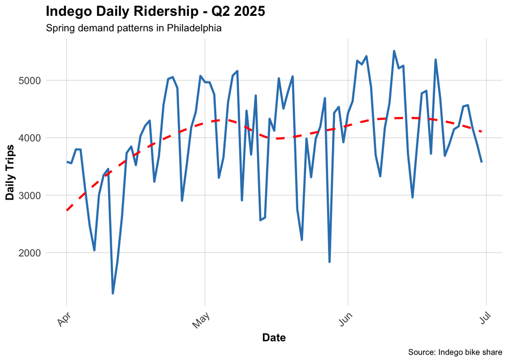

```r
# Daily trip counts
daily_trips_q2 <- indegoq2 %>%
  group_by(date) %>%
  summarize(trips = n())

ggplot(daily_trips_q2, aes(x = date, y = trips)) +
  geom_line(color = "#3182bd", linewidth = 1) +
  geom_smooth(se = FALSE, color = "red", linetype = "dashed") +
  labs(
    title = "Indego Daily Ridership - Q2 2025",
    subtitle = "Spring demand patterns in Philadelphia",
    x = "Date",
    y = "Daily Trips",
    caption = "Source: Indego bike share"
  ) +
  plotTheme
```

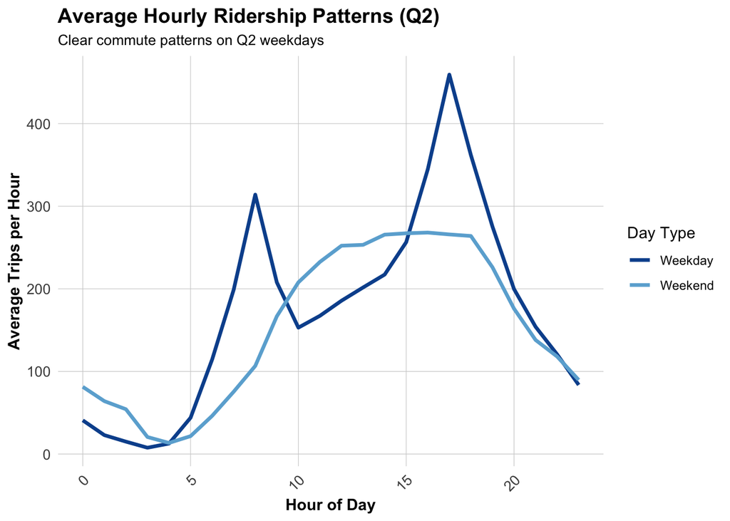

```r
# Average trips by hour and day type
hourly_patterns_q2 <- indegoq2 %>%
  group_by(hour, weekend) %>%
  summarize(avg_trips = n() / n_distinct(date)) %>%
  mutate(day_type = ifelse(weekend == 1, "Weekend", "Weekday"))

ggplot(hourly_patterns_q2, aes(x = hour, y = avg_trips, color = day_type)) +
  geom_line(linewidth = 1.2) +
  scale_color_manual(values = c("Weekday" = "#08519c", "Weekend" = "#6baed6")) +
  labs(
    title = "Average Hourly Ridership Patterns (Q2)",
    subtitle = "Clear commute patterns on Q2 weekdays",
    x = "Hour of Day",
    y = "Average Trips per Hour",
    color = "Day Type"
  ) +
  plotTheme
```

```r
# Most popular origin stations
top_stations_q2 <- indegoq2 %>%
  count(start_station, start_lat, start_lon, name = "trips") %>%
  arrange(desc(trips)) %>%
  head(20)

kable(top_stations_q2,
      caption = "Top 20 Indego Stations by Trip Origins (Q2)",
      format.args = list(big.mark = ",")) %>%
  kable_styling(bootstrap_options = c("striped", "hover"))
```

Top 20 Indego Stations by Trip Origins (Q2)

| start_station | start_lat | start_lon | trips |
| --- | --- | --- | --- |
| 3,010 | 39.94711 | -75.16618 | 6,278 |
| 3,032 | 39.94527 | -75.17971 | 4,751 |
| 3,359 | 39.94888 | -75.16978 | 4,181 |
| 3,028 | 39.94061 | -75.14958 | 4,028 |
| 3,163 | 39.94974 | -75.18097 | 4,000 |
| 3,020 | 39.94855 | -75.19007 | 3,946 |
| 3,185 | 39.95169 | -75.15888 | 3,914 |
| 3,066 | 39.94561 | -75.17348 | 3,899 |
| 3,022 | 39.95472 | -75.18323 | 3,856 |
| 3,054 | 39.96250 | -75.17420 | 3,767 |
| 3,161 | 39.95486 | -75.18091 | 3,629 |
| 3,362 | 39.94816 | -75.16226 | 3,552 |
| 3,063 | 39.94633 | -75.16980 | 3,516 |
| 3,213 | 39.93887 | -75.16663 | 3,332 |
| 3,059 | 39.96244 | -75.16121 | 3,320 |
| 3,012 | 39.94218 | -75.17747 | 3,264 |
| 3,007 | 39.94517 | -75.15993 | 3,242 |
| 3,061 | 39.95425 | -75.17761 | 3,193 |
| 3,101 | 39.94295 | -75.15955 | 3,170 |
| 3,296 | 39.95134 | -75.16758 | 3,088 |

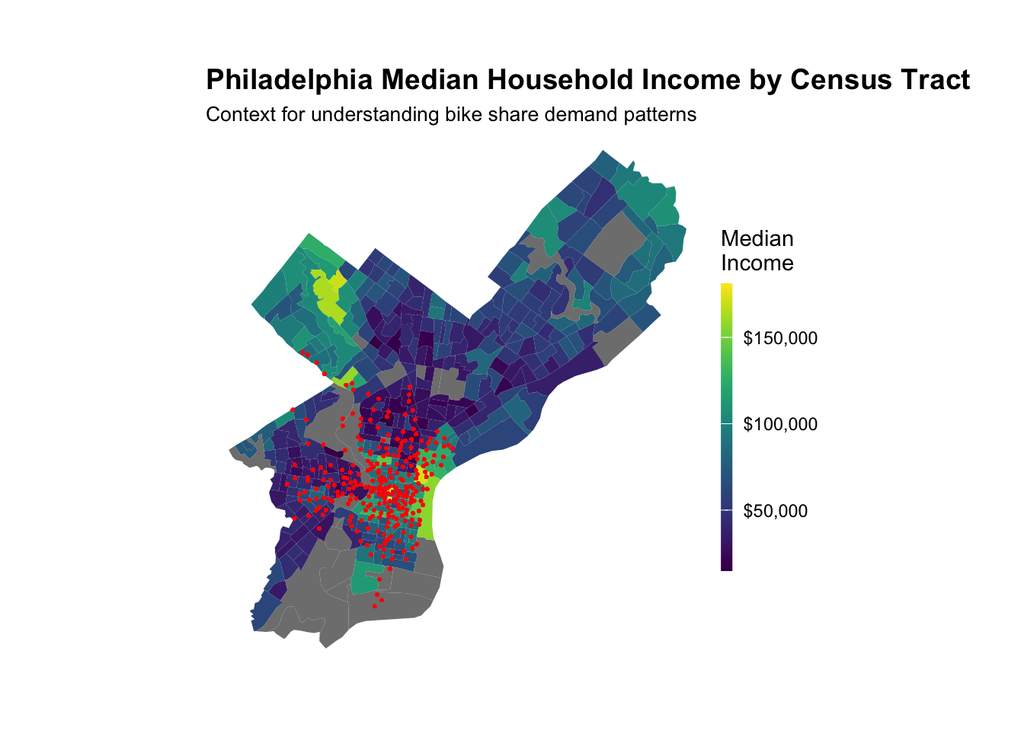

```r
# Map median income
ggplot() +
  geom_sf(data = philly_census, aes(fill = Med_Inc), color = NA) +
  scale_fill_viridis(
    option = "viridis",
    name = "Median\nIncome",
    labels = scales::dollar
  ) +
  labs(
    title = "Philadelphia Median Household Income by Census Tract",
    subtitle = "Context for understanding bike share demand patterns"
  ) +
  # Stations
  geom_point(
    data = indegoq2,
    aes(x = start_lon, y = start_lat),
    color = "red", size = 0.25, alpha = 0.6
  ) +
  mapTheme
```

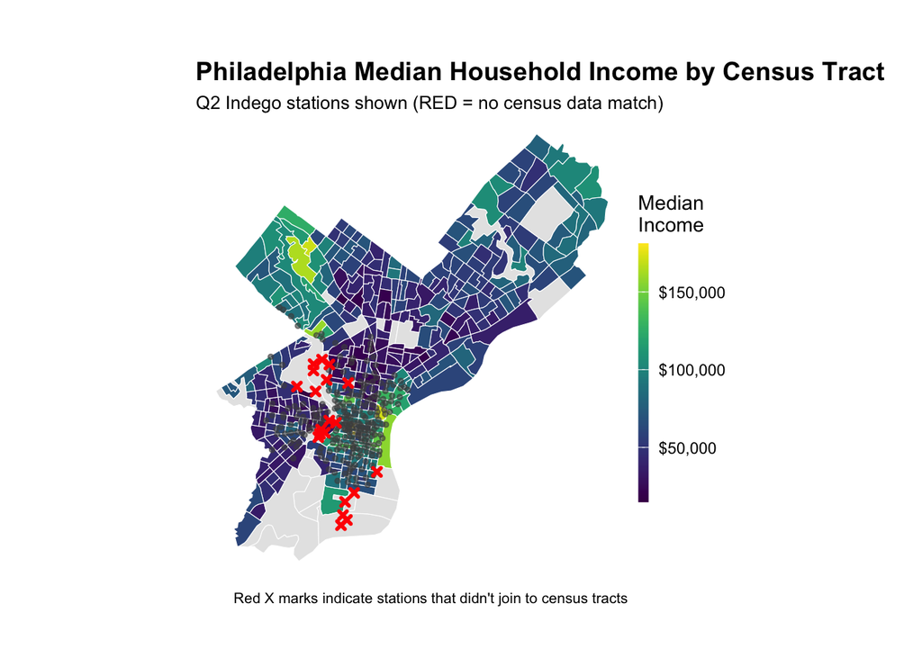

```r
# Create sf object for stations
stations_sf_q2 <- indegoq2 %>%
  distinct(start_station, start_lat, start_lon) %>%
  filter(!is.na(start_lat), !is.na(start_lon)) %>%
  st_as_sf(coords = c("start_lon", "start_lat"), crs = 4326)

# Spatial join to get census tract for each station
stations_census_q2 <- st_join(stations_sf_q2, philly_census, left = TRUE) %>%
  st_drop_geometry()

# Look at the result - investigate whether all of the stations joined to census data -- according to the map above there are stations in non-residential tracts.

stations_for_map_q2 <- indegoq2 %>%
  distinct(start_station, start_lat, start_lon) %>%
  filter(!is.na(start_lat), !is.na(start_lon)) %>%
  left_join(
    stations_census_q2 %>% select(start_station, Med_Inc),
    by = "start_station"
  ) %>%
  mutate(has_census = !is.na(Med_Inc))

# Add back to trip data
indego_census_q2 <- indegoq2 %>%
  left_join(
    stations_census_q2 %>%
      select(start_station, Med_Inc, Percent_Taking_Transit,
             Percent_White, Total_Pop),
    by = "start_station"
  )

# Prepare data for visualization
stations_for_map_q2 <- indegoq2 %>%
  distinct(start_station, start_lat, start_lon) %>%
  filter(!is.na(start_lat), !is.na(start_lon)) %>%
  left_join(
    stations_census_q2 %>% select(start_station, Med_Inc),
    by = "start_station"
  ) %>%
  mutate(has_census = !is.na(Med_Inc))

# Create the map showing problem stations
ggplot() +
  geom_sf(data = philly_census, aes(fill = Med_Inc), color = "white", size = 0.1) +
  scale_fill_viridis(
    option = "viridis",
    name = "Median\nIncome",
    labels = scales::dollar,
    na.value = "grey90"
  ) +
  # Stations with census data (small grey dots)
  geom_point(
    data = stations_for_map_q2 %>% filter(has_census),
    aes(x = start_lon, y = start_lat),
    color = "grey30", size = 1, alpha = 0.6
  ) +
  # Stations WITHOUT census data (red X marks the spot)
  geom_point(
    data = stations_for_map_q2 %>% filter(!has_census),
    aes(x = start_lon, y = start_lat),
    color = "red", size = 1, shape = 4, stroke = 1.5
  ) +
  labs(
    title = "Philadelphia Median Household Income by Census Tract",
    subtitle = "Q2 Indego stations shown (RED = no census data match)",
    caption = "Red X marks indicate stations that didn't join to census tracts"
  ) +
  mapTheme
```

```r
# Identify which stations to keep
valid_stations_q2 <- stations_census_q2 %>%
  filter(!is.na(Med_Inc)) %>%
  pull(start_station)

# Filter trip data to valid stations only
indego_census_q2 <- indegoq2 %>%
  filter(start_station %in% valid_stations) %>%
  left_join(
    stations_census_q2 %>%
      select(start_station, Med_Inc, Percent_Taking_Transit,
             Percent_White, Total_Pop),
    by = "start_station"
  )
```

```r
# Get weather from Philadelphia International Airport (KPHL)
# This covers Q1 2025: January 1 - March 31
weather_data_q2 <- riem_measures(
  station = "PHL",  # Philadelphia International Airport
  date_start = "2025-04-01",
  date_end = "2025-06-30"
)

# Process weather data
weather_processed_q2 <- weather_data_q2 %>%
  mutate(
    interval60 = floor_date(valid, unit = "hour"),
    Temperature = tmpf,  # Temperature in Fahrenheit
    Precipitation = ifelse(is.na(p01i), 0, p01i),  # Hourly precip in inches
    Wind_Speed = sknt  # Wind speed in knots
  ) %>%
  select(interval60, Temperature, Precipitation, Wind_Speed) %>%
  distinct(interval60, .keep_all = TRUE)

# Check for missing hours and interpolate if needed
weather_complete_q2 <- weather_processed_q2 %>%
  complete(interval60 = seq(min(interval60), max(interval60), by = "hour")) %>%
  fill(Temperature, Precipitation, Wind_Speed, .direction = "down")

# Look at the weather
summary(weather_complete_q2 %>% select(Temperature, Precipitation, Wind_Speed))
```

```
  Temperature     Precipitation        Wind_Speed
 Min.   : 33.00   Min.   :0.000000   Min.   : 0.000
 1st Qu.: 57.00   1st Qu.:0.000000   1st Qu.: 5.000
 Median : 66.00   Median :0.000000   Median : 8.000
 Mean   : 65.62   Mean   :0.002024   Mean   : 8.125
 3rd Qu.: 73.00   3rd Qu.:0.000000   3rd Qu.:11.000
 Max.   :100.00   Max.   :0.590000   Max.   :27.000
```

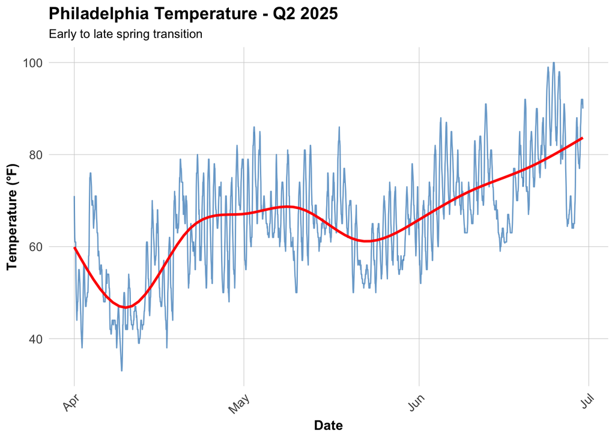

```r
ggplot(weather_complete_q2, aes(x = interval60, y = Temperature)) +
  geom_line(color = "#3182bd", alpha = 0.7) +
  geom_smooth(se = FALSE, color = "red") +
  labs(
    title = "Philadelphia Temperature - Q2 2025",
    subtitle = "Early to late spring transition",
    x = "Date",
    y = "Temperature (°F)"
  ) +
  plotTheme
```

```r
# Count trips by station-hour
trips_panel_q2 <- indego_census_q2 %>%
  group_by(interval60, start_station, start_lat, start_lon,
           Med_Inc, Percent_Taking_Transit, Percent_White, Total_Pop) %>%
  summarize(Trip_Count = n()) %>%
  ungroup()

# How many station-hour observations?
nrow(trips_panel_q2)
```

```
[1] 177224
```

```r
# How many unique stations?
length(unique(trips_panel_q2$start_station))
```

```
[1] 243
```

```r
# How many unique hours?
length(unique(trips_panel_q2$interval60))
```

```
[1] 2177
```

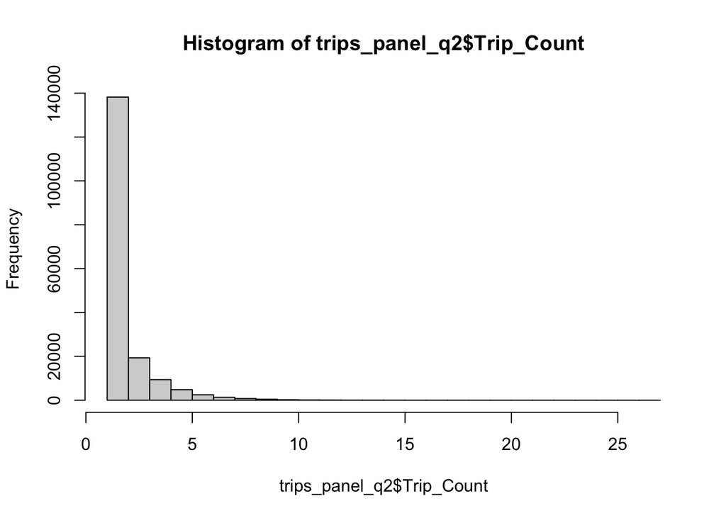

```r
hist(trips_panel_q2$Trip_Count)
```

```r
# Calculate expected panel size
n_stations_q2 <- length(unique(trips_panel_q2$start_station))
n_hours_q2 <- length(unique(trips_panel_q2$interval60))
expected_rows_q2 <- n_stations_q2 * n_hours_q2

cat("Expected panel rows:", format(expected_rows_q2, big.mark = ","), "\n")
```

```
Expected panel rows: 529,011
```

```r
cat("Current rows:", format(nrow(trips_panel_q2), big.mark = ","), "\n")
```

```
Current rows: 177,224
```

```r
cat("Missing rows:", format(expected_rows_q2 - nrow(trips_panel_q2), big.mark = ","), "\n")
```

```
Missing rows: 351,787
```

```r
# Create complete panel
study_panel_q2 <- expand_grid(
  interval60 = unique(trips_panel_q2$interval60),
  start_station = unique(trips_panel_q2$start_station)
) %>%
  # Join trip counts
  left_join(trips_panel_q2 %>%
              select(interval60, start_station, Trip_Count),
            by = c("interval60", "start_station")) %>%
  # Replace NA trip counts with 0
  mutate(Trip_Count = replace_na(Trip_Count, 0))

glimpse(study_panel_q2)
```

```
Rows: 529,011
Columns: 3
$ interval60    <dttm> 2025-04-01, 2025-04-01, 2025-04-01, 2025-04-01, 2025-04…
$ start_station <dbl> 3022, 3040, 3054, 3280, 3301, 3396, 3158, 3371, 3374, 30…
$ Trip_Count    <int> 1, 1, 1, 1, 1, 1, 0, 0, 0, 0, 0, 0, 0, 0, 0, 0, 0, 0, 0,…
```

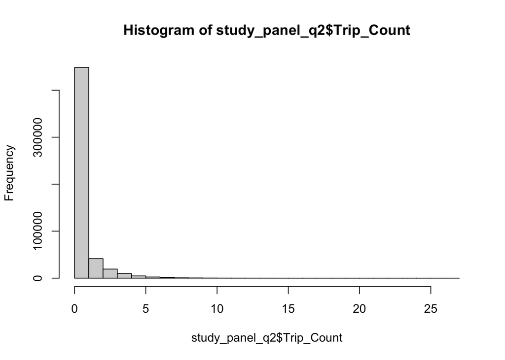

```r
hist(study_panel_q2$Trip_Count)
```

```r
# Fill in station attributes (they're the same for all hours)
station_attributes_q2 <- trips_panel_q2 %>%
  group_by(start_station) %>%
  summarize(
    start_lat = first(start_lat),
    start_lon = first(start_lon),
    Med_Inc = first(Med_Inc),
    Percent_Taking_Transit = first(Percent_Taking_Transit),
    Percent_White = first(Percent_White),
    Total_Pop = first(Total_Pop)
  )

glimpse(station_attributes_q2)
```

```
Rows: 243
Columns: 7
$ start_station          <dbl> 3005, 3006, 3007, 3008, 3009, 3010, 3012, 3014,…
$ start_lat              <dbl> 39.94733, 39.95220, 39.94517, 39.98081, 39.9557…
$ start_lon              <dbl> -75.14403, -75.20311, -75.15993, -75.15067, -75…
$ Med_Inc                <dbl> 144922, 21064, 58557, 22244, 37674, 88583, 1385…
$ Percent_Taking_Transit <dbl> 11.742827, 9.418565, 11.401515, 27.430556, 10.8…
$ Percent_White          <dbl> 86.29640, 46.88109, 62.85341, 39.65227, 60.2169…
$ Total_Pop              <dbl> 3583, 6156, 4598, 5349, 7375, 3134, 3643, 3914,…
```

```r
study_panel_q2 <- study_panel_q2 %>%
  left_join(station_attributes, by = "start_station")

glimpse(study_panel_q2)
```

```
Rows: 529,011
Columns: 9
$ interval60             <dttm> 2025-04-01, 2025-04-01, 2025-04-01, 2025-04-01…
$ start_station          <dbl> 3022, 3040, 3054, 3280, 3301, 3396, 3158, 3371,…
$ Trip_Count             <int> 1, 1, 1, 1, 1, 1, 0, 0, 0, 0, 0, 0, 0, 0, 0, 0,…
$ start_lat              <dbl> 39.95472, 39.96289, 39.96250, 39.93968, 39.9502…
$ start_lon              <dbl> -75.18323, -75.16606, -75.17420, -75.21362, -75…
$ Med_Inc                <dbl> 29464, 79694, 88936, 39547, 86809, 49493, 61583…
$ Percent_Taking_Transit <dbl> 5.081301, 14.574899, 11.852149, 25.837629, 25.9…
$ Percent_White          <dbl> 54.396043, 61.073826, 60.379375, 9.203540, 79.6…
$ Total_Pop              <dbl> 6267, 2235, 3743, 3955, 1807, 3742, 4029, 3486,…
```

```r
# Verify we have complete panel
cat("Complete panel rows:", format(nrow(study_panel_q2), big.mark = ","), "\n")
```

```
Complete panel rows: 529,011
```

```r
study_panel_q2 <- study_panel_q2 %>%
  mutate(
    week = week(interval60),
    month = month(interval60, label = TRUE),
    dotw = wday(interval60, label = TRUE),
    hour = hour(interval60),
    date = as.Date(interval60),
    weekend = ifelse(dotw %in% c("Sat", "Sun"), 1, 0),
    rush_hour = ifelse(hour %in% c(7, 8, 9, 16, 17, 18), 1, 0)
  )

glimpse(study_panel_q2)
```

```
Rows: 529,011
Columns: 16
$ interval60             <dttm> 2025-04-01, 2025-04-01, 2025-04-01, 2025-04-01…
$ start_station          <dbl> 3022, 3040, 3054, 3280, 3301, 3396, 3158, 3371,…
$ Trip_Count             <int> 1, 1, 1, 1, 1, 1, 0, 0, 0, 0, 0, 0, 0, 0, 0, 0,…
$ start_lat              <dbl> 39.95472, 39.96289, 39.96250, 39.93968, 39.9502…
$ start_lon              <dbl> -75.18323, -75.16606, -75.17420, -75.21362, -75…
$ Med_Inc                <dbl> 29464, 79694, 88936, 39547, 86809, 49493, 61583…
$ Percent_Taking_Transit <dbl> 5.081301, 14.574899, 11.852149, 25.837629, 25.9…
$ Percent_White          <dbl> 54.396043, 61.073826, 60.379375, 9.203540, 79.6…
$ Total_Pop              <dbl> 6267, 2235, 3743, 3955, 1807, 3742, 4029, 3486,…
$ week                   <dbl> 13, 13, 13, 13, 13, 13, 13, 13, 13, 13, 13, 13,…
$ month                  <ord> Apr, Apr, Apr, Apr, Apr, Apr, Apr, Apr, Apr, Ap…
$ dotw                   <ord> Tue, Tue, Tue, Tue, Tue, Tue, Tue, Tue, Tue, Tu…
$ hour                   <int> 0, 0, 0, 0, 0, 0, 0, 0, 0, 0, 0, 0, 0, 0, 0, 0,…
$ date                   <date> 2025-04-01, 2025-04-01, 2025-04-01, 2025-04-01…
$ weekend                <dbl> 0, 0, 0, 0, 0, 0, 0, 0, 0, 0, 0, 0, 0, 0, 0, 0,…
$ rush_hour              <dbl> 0, 0, 0, 0, 0, 0, 0, 0, 0, 0, 0, 0, 0, 0, 0, 0,…
```

```r
study_panel_q2 <- study_panel_q2 %>%
  left_join(weather_complete_q2, by = "interval60")

glimpse(study_panel_q2)
```

```
Rows: 529,011
Columns: 19
$ interval60             <dttm> 2025-04-01, 2025-04-01, 2025-04-01, 2025-04-01…
$ start_station          <dbl> 3022, 3040, 3054, 3280, 3301, 3396, 3158, 3371,…
$ Trip_Count             <int> 1, 1, 1, 1, 1, 1, 0, 0, 0, 0, 0, 0, 0, 0, 0, 0,…
$ start_lat              <dbl> 39.95472, 39.96289, 39.96250, 39.93968, 39.9502…
$ start_lon              <dbl> -75.18323, -75.16606, -75.17420, -75.21362, -75…
$ Med_Inc                <dbl> 29464, 79694, 88936, 39547, 86809, 49493, 61583…
$ Percent_Taking_Transit <dbl> 5.081301, 14.574899, 11.852149, 25.837629, 25.9…
$ Percent_White          <dbl> 54.396043, 61.073826, 60.379375, 9.203540, 79.6…
$ Total_Pop              <dbl> 6267, 2235, 3743, 3955, 1807, 3742, 4029, 3486,…
$ week                   <dbl> 13, 13, 13, 13, 13, 13, 13, 13, 13, 13, 13, 13,…
$ month                  <ord> Apr, Apr, Apr, Apr, Apr, Apr, Apr, Apr, Apr, Ap…
$ dotw                   <ord> Tue, Tue, Tue, Tue, Tue, Tue, Tue, Tue, Tue, Tu…
$ hour                   <int> 0, 0, 0, 0, 0, 0, 0, 0, 0, 0, 0, 0, 0, 0, 0, 0,…
$ date                   <date> 2025-04-01, 2025-04-01, 2025-04-01, 2025-04-01…
$ weekend                <dbl> 0, 0, 0, 0, 0, 0, 0, 0, 0, 0, 0, 0, 0, 0, 0, 0,…
$ rush_hour              <dbl> 0, 0, 0, 0, 0, 0, 0, 0, 0, 0, 0, 0, 0, 0, 0, 0,…
$ Temperature            <dbl> 71, 71, 71, 71, 71, 71, 71, 71, 71, 71, 71, 71,…
$ Precipitation          <dbl> 0, 0, 0, 0, 0, 0, 0, 0, 0, 0, 0, 0, 0, 0, 0, 0,…
$ Wind_Speed             <dbl> 8, 8, 8, 8, 8, 8, 8, 8, 8, 8, 8, 8, 8, 8, 8, 8,…
```

```r
# Check for missing values
summary(study_panel_q2 %>% select(Trip_Count, Temperature, Precipitation))
```

```
   Trip_Count       Temperature     Precipitation
 Min.   : 0.0000   Min.   : 33.00   Min.   :0.000
 1st Qu.: 0.0000   1st Qu.: 57.00   1st Qu.:0.000
 Median : 0.0000   Median : 66.00   Median :0.000
 Mean   : 0.6418   Mean   : 65.64   Mean   :0.002
 3rd Qu.: 1.0000   3rd Qu.: 74.00   3rd Qu.:0.000
 Max.   :27.0000   Max.   :100.00   Max.   :0.590
                   NA's   :5832     NA's   :5832
```

```r
# Sort by station and time
study_panel_q2 <- study_panel_q2 %>%
  arrange(start_station, interval60)

# Create lag variables WITHIN each station
study_panel_q2 <- study_panel_q2 %>%
  group_by(start_station) %>%
  mutate(
    lag1Hour = lag(Trip_Count, 1),
    lag2Hours = lag(Trip_Count, 2),
    lag3Hours = lag(Trip_Count, 3),
    lag12Hours = lag(Trip_Count, 12),
    lag1day = lag(Trip_Count, 24)
  ) %>%
  ungroup()

# Remove rows with NA lags (first 24 hours for each station)
study_panel_complete_q2 <- study_panel_q2 %>%
  filter(!is.na(lag1day))

cat("Rows after removing NA lags:", format(nrow(study_panel_complete), big.mark = ","), "\n")
```

```
Rows after removing NA lags: 505,988
```

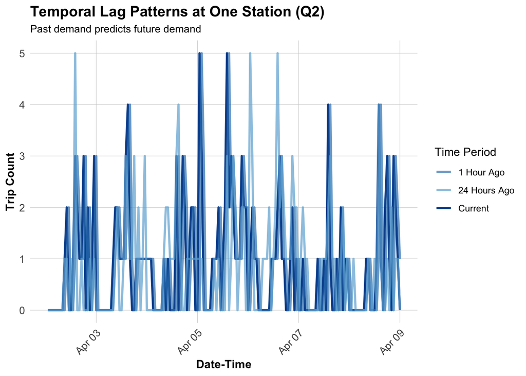

```r
# Sample one station to visualize
example_station_q2 <- study_panel_complete_q2 %>%
  filter(start_station == first(start_station)) %>%
  head(168)  # One week

# Plot actual vs lagged demand
ggplot(example_station_q2, aes(x = interval60)) +
  geom_line(aes(y = Trip_Count, color = "Current"), linewidth = 1) +
  geom_line(aes(y = lag1Hour, color = "1 Hour Ago"), linewidth = 1, alpha = 0.7) +
  geom_line(aes(y = lag1day, color = "24 Hours Ago"), linewidth = 1, alpha = 0.7) +
  scale_color_manual(values = c(
    "Current" = "#08519c",
    "1 Hour Ago" = "#3182bd",
    "24 Hours Ago" = "#6baed6"
  )) +
  labs(
    title = "Temporal Lag Patterns at One Station (Q2)",
    subtitle = "Past demand predicts future demand",
    x = "Date-Time",
    y = "Trip Count",
    color = "Time Period"
  ) +
  plotTheme
```

```r
# Split by week
# Q1 has weeks 1-13 (Jan-Mar)
# Train on weeks 1-9 (Jan 1 - early March)
# Test on weeks 10-13 (rest of March)

# Q2 has weeks 14-26 (Apr-Jun)
# Train on weeks 14-22
# Test on weeks 23-26

# Which stations have trips in BOTH early and late periods?
early_stations_q2 <- study_panel_complete_q2 %>%
  filter(week < 23) %>%
  filter(Trip_Count > 0) %>%
  distinct(start_station) %>%
  pull(start_station)

late_stations_q2 <- study_panel_complete_q2 %>%
  filter(week >= 23) %>%
  filter(Trip_Count > 0) %>%
  distinct(start_station) %>%
  pull(start_station)

# Keep only stations that appear in BOTH periods
common_stations_q2 <- intersect(early_stations_q2, late_stations_q2)

# Filter panel to only common stations
study_panel_complete_q2 <- study_panel_complete_q2 %>%
  filter(start_station %in% common_stations_q2)

# NOW create train/test split
train_q2 <- study_panel_complete_q2 %>%
  filter(week < 23)

test_q2 <- study_panel_complete_q2 %>%
  filter(week >= 23)

cat("Training observations:", format(nrow(train), big.mark = ","), "\n")
```

```
Training observations: 352,240
```

```r
cat("Testing observations:", format(nrow(test), big.mark = ","), "\n")
```

```
Testing observations: 153,748
```

```r
cat("Training date range:", min(train$date), "to", max(train$date), "\n")
```

```
Training date range: 20090 to 20151
```

```r
cat("Testing date range:", min(test$date), "to", max(test$date), "\n")
```

```
Testing date range: 20152 to 20178
```

```r
# Create day of week factor with treatment (dummy) coding
train_q2 <- train_q2 %>%
  mutate(dotw_simple = factor(dotw, levels = c("Mon", "Tue", "Wed", "Thu", "Fri", "Sat", "Sun")))

# Set contrasts to treatment coding (dummy variables)
contrasts(train_q2$dotw_simple) <- contr.treatment(7)

# Now run the model
model1_q2 <- lm(
  Trip_Count ~ as.factor(hour) + dotw_simple + Temperature + Precipitation,
  data = train_q2
)

summary(model1_q2)
```

```
Call:
lm(formula = Trip_Count ~ as.factor(hour) + dotw_simple + Temperature +
    Precipitation, data = train_q2)

Residuals:
    Min      1Q  Median      3Q     Max
-1.6858 -0.6753 -0.2081  0.1938 25.4707

Coefficients:
                    Estimate Std. Error t value             Pr(>|t|)
(Intercept)       -0.5686869  0.0166327 -34.191 < 0.0000000000000002 ***
as.factor(hour)1  -0.0465109  0.0131972  -3.524             0.000425 ***
as.factor(hour)2  -0.0584620  0.0132033  -4.428   0.0000095214865106 ***
as.factor(hour)3  -0.1013593  0.0132145  -7.670   0.0000000000000172 ***
as.factor(hour)4  -0.0811460  0.0132355  -6.131   0.0000000008744761 ***
as.factor(hour)5   0.0163175  0.0132492   1.232             0.218106
as.factor(hour)6   0.2421178  0.0132107  18.327 < 0.0000000000000002 ***
as.factor(hour)7   0.5041329  0.0132219  38.129 < 0.0000000000000002 ***
as.factor(hour)8   0.8719832  0.0132317  65.901 < 0.0000000000000002 ***
as.factor(hour)9   0.6537179  0.0132576  49.309 < 0.0000000000000002 ***
as.factor(hour)10  0.5316157  0.0132277  40.189 < 0.0000000000000002 ***
as.factor(hour)11  0.5719106  0.0131943  43.345 < 0.0000000000000002 ***
as.factor(hour)12  0.6073709  0.0131628  46.143 < 0.0000000000000002 ***
as.factor(hour)13  0.6307510  0.0131457  47.982 < 0.0000000000000002 ***
as.factor(hour)14  0.6633283  0.0131388  50.486 < 0.0000000000000002 ***
as.factor(hour)15  0.7442278  0.0131461  56.612 < 0.0000000000000002 ***
as.factor(hour)16  0.9102063  0.0131570  69.180 < 0.0000000000000002 ***
as.factor(hour)17  1.2230320  0.0131742  92.836 < 0.0000000000000002 ***
as.factor(hour)18  0.9756369  0.0131908  73.963 < 0.0000000000000002 ***
as.factor(hour)19  0.6827064  0.0131939  51.744 < 0.0000000000000002 ***
as.factor(hour)20  0.4263723  0.0131924  32.320 < 0.0000000000000002 ***
as.factor(hour)21  0.2729402  0.0131842  20.702 < 0.0000000000000002 ***
as.factor(hour)22  0.1878217  0.0131630  14.269 < 0.0000000000000002 ***
as.factor(hour)23  0.0810361  0.0131469   6.164   0.0000000007106143 ***
dotw_simple2       0.0334004  0.0070936   4.709   0.0000024962777833 ***
dotw_simple3      -0.0061021  0.0070864  -0.861             0.389186
dotw_simple4       0.0535531  0.0070462   7.600   0.0000000000000296 ***
dotw_simple5      -0.0258789  0.0070584  -3.666             0.000246 ***
dotw_simple6      -0.0456751  0.0070596  -6.470   0.0000000000981664 ***
dotw_simple7      -0.0782108  0.0070402 -11.109 < 0.0000000000000002 ***
Temperature        0.0123785  0.0002068  59.856 < 0.0000000000000002 ***
Precipitation     -0.8323861  0.0957818  -8.690 < 0.0000000000000002 ***
---
Signif. codes:  0 '***' 0.001 '**' 0.01 '*' 0.05 '.' 0.1 ' ' 1

Residual standard error: 1.138 on 364178 degrees of freedom
Multiple R-squared:  0.1149,    Adjusted R-squared:  0.1148
F-statistic:  1525 on 31 and 364178 DF,  p-value: < 0.00000000000000022
```

```r
model2_q2 <- lm(
  Trip_Count ~ as.factor(hour) + dotw_simple + Temperature + Precipitation +
    lag1Hour + lag3Hours + lag1day,
  data = train_q2
)

summary(model2_q2)
```

```
Call:
lm(formula = Trip_Count ~ as.factor(hour) + dotw_simple + Temperature +
    Precipitation + lag1Hour + lag3Hours + lag1day, data = train_q2)

Residuals:
     Min       1Q   Median       3Q      Max
-10.6088  -0.4873  -0.1343   0.1306  20.6903

Coefficients:
                    Estimate Std. Error t value             Pr(>|t|)
(Intercept)       -0.2786416  0.0148137 -18.810 < 0.0000000000000002 ***
as.factor(hour)1   0.0007753  0.0117316   0.066              0.94731
as.factor(hour)2   0.0187694  0.0117399   1.599              0.10987
as.factor(hour)3   0.0027994  0.0117540   0.238              0.81175
as.factor(hour)4   0.0353746  0.0117754   3.004              0.00266 **
as.factor(hour)5   0.1098805  0.0117895   9.320 < 0.0000000000000002 ***
as.factor(hour)6   0.2602957  0.0117652  22.124 < 0.0000000000000002 ***
as.factor(hour)7   0.4006436  0.0117959  33.965 < 0.0000000000000002 ***
as.factor(hour)8   0.6054272  0.0118514  51.085 < 0.0000000000000002 ***
as.factor(hour)9   0.3153294  0.0118651  26.576 < 0.0000000000000002 ***
as.factor(hour)10  0.2552638  0.0117944  21.643 < 0.0000000000000002 ***
as.factor(hour)11  0.2773081  0.0117715  23.558 < 0.0000000000000002 ***
as.factor(hour)12  0.3254183  0.0117373  27.725 < 0.0000000000000002 ***
as.factor(hour)13  0.3476973  0.0117274  29.648 < 0.0000000000000002 ***
as.factor(hour)14  0.3603884  0.0117262  30.734 < 0.0000000000000002 ***
as.factor(hour)15  0.4090602  0.0117427  34.835 < 0.0000000000000002 ***
as.factor(hour)16  0.5104931  0.0117779  43.343 < 0.0000000000000002 ***
as.factor(hour)17  0.7006963  0.0118575  59.093 < 0.0000000000000002 ***
as.factor(hour)18  0.4217082  0.0118731  35.518 < 0.0000000000000002 ***
as.factor(hour)19  0.2383102  0.0118160  20.168 < 0.0000000000000002 ***
as.factor(hour)20  0.0794164  0.0118063   6.727      0.0000000000174 ***
as.factor(hour)21  0.0519485  0.0117587   4.418      0.0000099706690 ***
as.factor(hour)22  0.0547637  0.0117135   4.675      0.0000029369089 ***
as.factor(hour)23  0.0200516  0.0116878   1.716              0.08624 .
dotw_simple2       0.0117492  0.0063056   1.863              0.06242 .
dotw_simple3      -0.0405561  0.0063025  -6.435      0.0000000001237 ***
dotw_simple4       0.0264815  0.0062638   4.228      0.0000236126344 ***
dotw_simple5      -0.0378928  0.0062759  -6.038      0.0000000015635 ***
dotw_simple6      -0.0361645  0.0062760  -5.762      0.0000000083024 ***
dotw_simple7      -0.0618000  0.0062595  -9.873 < 0.0000000000000002 ***
Temperature        0.0047629  0.0001856  25.660 < 0.0000000000000002 ***
Precipitation     -0.4003759  0.0851674  -4.701      0.0000025892524 ***
lag1Hour           0.2536095  0.0015986 158.644 < 0.0000000000000002 ***
lag3Hours          0.1191622  0.0015658  76.105 < 0.0000000000000002 ***
lag1day            0.2486732  0.0015646 158.933 < 0.0000000000000002 ***
---
Signif. codes:  0 '***' 0.001 '**' 0.01 '*' 0.05 '.' 0.1 ' ' 1

Residual standard error: 1.011 on 364175 degrees of freedom
Multiple R-squared:  0.3007,    Adjusted R-squared:  0.3007
F-statistic:  4606 on 34 and 364175 DF,  p-value: < 0.00000000000000022
```

```r
model3_q2 <- lm(
  Trip_Count ~ as.factor(hour) + dotw_simple + Temperature + Precipitation +
    lag1Hour + lag3Hours + lag1day +
    Med_Inc + Percent_Taking_Transit + Percent_White,
  data = train_q2
)

summary(model3_q2)
```

```
Call:
lm(formula = Trip_Count ~ as.factor(hour) + dotw_simple + Temperature +
    Precipitation + lag1Hour + lag3Hours + lag1day + Med_Inc +
    Percent_Taking_Transit + Percent_White, data = train_q2)

Residuals:
     Min       1Q   Median       3Q      Max
-10.0484  -0.4849  -0.1412   0.1830  20.9227

Coefficients:
                             Estimate     Std. Error t value
(Intercept)            -0.42070035678  0.01631938636 -25.779
as.factor(hour)1       -0.00182979642  0.01168144924  -0.157
as.factor(hour)2        0.01415556894  0.01168990872   1.211
as.factor(hour)3       -0.00368640553  0.01170419500  -0.315
as.factor(hour)4        0.02807380830  0.01172574116   2.394
as.factor(hour)5        0.10351430373  0.01173954559   8.818
as.factor(hour)6        0.25710944906  0.01171500115  21.947
as.factor(hour)7        0.40296584628  0.01174541623  34.308
as.factor(hour)8        0.61564806722  0.01180204385  52.165
as.factor(hour)9        0.32989140983  0.01181715705  27.916
as.factor(hour)10       0.26869912530  0.01174630693  22.875
as.factor(hour)11       0.29393834598  0.01172483019  25.070
as.factor(hour)12       0.33977180618  0.01168980265  29.066
as.factor(hour)13       0.36120138993  0.01167971891  30.926
as.factor(hour)14       0.37502036570  0.01167887478  32.111
as.factor(hour)15       0.42541336581  0.01169604588  36.372
as.factor(hour)16       0.52998335621  0.01173265970  45.172
as.factor(hour)17       0.72599568402  0.01181531299  61.445
as.factor(hour)18       0.44860348729  0.01183201586  37.914
as.factor(hour)19       0.26147631214  0.01177270461  22.210
as.factor(hour)20       0.10044590305  0.01176174770   8.540
as.factor(hour)21       0.06594364646  0.01171102447   5.631
as.factor(hour)22       0.06310023254  0.01166431084   5.410
as.factor(hour)23       0.02362097038  0.01163796267   2.030
dotw_simple2            0.01295536503  0.00627867463   2.063
dotw_simple3           -0.03887226470  0.00627558566  -6.194
dotw_simple4            0.02799080820  0.00623702286   4.488
dotw_simple5           -0.03739476363  0.00624903387  -5.984
dotw_simple6           -0.03682843761  0.00624915188  -5.893
```

[output cut: 39 more lines]

```
dotw_simple7           < 0.0000000000000002 ***
Temperature            < 0.0000000000000002 ***
Precipitation                0.000000459588 ***
lag1Hour               < 0.0000000000000002 ***
lag3Hours              < 0.0000000000000002 ***
lag1day                < 0.0000000000000002 ***
Med_Inc                < 0.0000000000000002 ***
Percent_Taking_Transit < 0.0000000000000002 ***
Percent_White          < 0.0000000000000002 ***
---
Signif. codes:  0 '***' 0.001 '**' 0.01 '*' 0.05 '.' 0.1 ' ' 1

Residual standard error: 1.007 on 364172 degrees of freedom
Multiple R-squared:  0.3067,    Adjusted R-squared:  0.3066
F-statistic:  4354 on 37 and 364172 DF,  p-value: < 0.00000000000000022
```

```r
model4_q2 <- lm(
  Trip_Count ~ as.factor(hour) + dotw_simple + Temperature + Precipitation +
    lag1Hour + lag3Hours + lag1day +
    Med_Inc + Percent_Taking_Transit + Percent_White +
    as.factor(start_station),
  data = train_q2
)

# Summary too long with all station dummies, just show key metrics
cat("Model 4Q2 R-squared:", summary(model4_q2)$r.squared, "\n")
```

```
Model 4Q2 R-squared: 0.3327597
```

```r
cat("Model 4Q2 Adj R-squared:", summary(model4_q2)$adj.r.squared, "\n")
```

```
Model 4Q2 Adj R-squared: 0.3322555
```

```r
model5_q2 <- lm(
  Trip_Count ~ as.factor(hour) + dotw_simple + Temperature + Precipitation +
    lag1Hour + lag3Hours + lag1day + rush_hour + as.factor(month) +
    Med_Inc + Percent_Taking_Transit + Percent_White +
    as.factor(start_station) +
    rush_hour * weekend,  # Rush hour effects different on weekends
  data = train_q2
)

cat("Model 5Q2 R-squared:", summary(model5)$r.squared, "\n")
```

```
Model 5Q2 R-squared: 0.2671713
```

```r
cat("Model 5Q2 Adj R-squared:", summary(model5)$adj.r.squared, "\n")
```

```
Model 5Q2 Adj R-squared: 0.2666008
```

```r
# Get predictions on test set

# Create day of week factor with treatment (dummy) coding
test_q2 <- test_q2 %>%
  mutate(dotw_simple = factor(dotw, levels = c("Mon", "Tue", "Wed", "Thu", "Fri", "Sat", "Sun")))

# Set contrasts to treatment coding (dummy variables)
contrasts(test_q2$dotw_simple) <- contr.treatment(7)

test_q2 <- test_q2 %>%
  mutate(
    pred1 = predict(model1_q2, newdata = test_q2),
    pred2 = predict(model2_q2, newdata = test_q2),
    pred3 = predict(model3_q2, newdata = test_q2),
    pred4 = predict(model4_q2, newdata = test_q2),
    pred5 = predict(model5_q2, newdata = test_q2)
  )

# Calculate MAE for each model
mae_results_q2 <- data.frame(
  Model = c(
    "1. Time + Weather",
    "2. + Temporal Lags",
    "3. + Demographics",
    "4. + Station FE",
    "5. + Rush Hour Interaction"
  ),
  MAE = c(
    mean(abs(test_q2$Trip_Count - test_q2$pred1), na.rm = TRUE),
    mean(abs(test_q2$Trip_Count - test_q2$pred2), na.rm = TRUE),
    mean(abs(test_q2$Trip_Count - test_q2$pred3), na.rm = TRUE),
    mean(abs(test_q2$Trip_Count - test_q2$pred4), na.rm = TRUE),
    mean(abs(test_q2$Trip_Count - test_q2$pred5), na.rm = TRUE)
  )
)

kable(mae_results_q2,
      digits = 2,
      caption = "Mean Absolute Error by Model (Test Set) (Q2)",
      col.names = c("Model", "MAE (trips)")) %>%
  kable_styling(bootstrap_options = c("striped", "hover"))
```

Mean Absolute Error by Model (Test Set) (Q2)

| Model | MAE (trips) |
| --- | --- |
| 1. Time + Weather | 0.84 |
| 2. + Temporal Lags | 0.70 |
| 3. + Demographics | 0.70 |
| 4. + Station FE | 0.70 |
| 5. + Rush Hour Interaction | 0.72 |

3. **Compare results** to Q1 2025:
   - How do MAE values compare? Why might they differ?
   - Are temporal patterns different (e.g., summer vs. winter)?
   - Which features are most important in your quarter?

```r
mae_results$Quarter <- "Q1"
mae_results_q2$Quarter <- "Q2"

mae_results_combined <- rbind(mae_results, mae_results_q2)

kable(mae_results_combined,
      digits = 2,
      caption = "Mean Absolute Error by Model (Test Set)",
      col.names = c("Model", "MAE (trips)", "Quarter")) %>%
  kable_styling(bootstrap_options = c("striped", "hover"))
```

Mean Absolute Error by Model (Test Set)

| Model | MAE (trips) | Quarter |
| --- | --- | --- |
| 1. Time + Weather | 0.62 | Q1 |
| 2. + Temporal Lags | 0.54 | Q1 |
| 3. + Demographics | 0.53 | Q1 |
| 4. + Station FE | 0.53 | Q1 |
| 5. + Rush Hour Interaction | 0.53 | Q1 |
| 1. Time + Weather | 0.84 | Q2 |
| 2. + Temporal Lags | 0.70 | Q2 |
| 3. + Demographics | 0.70 | Q2 |
| 4. + Station FE | 0.70 | Q2 |
| 5. + Rush Hour Interaction | 0.72 | Q2 |

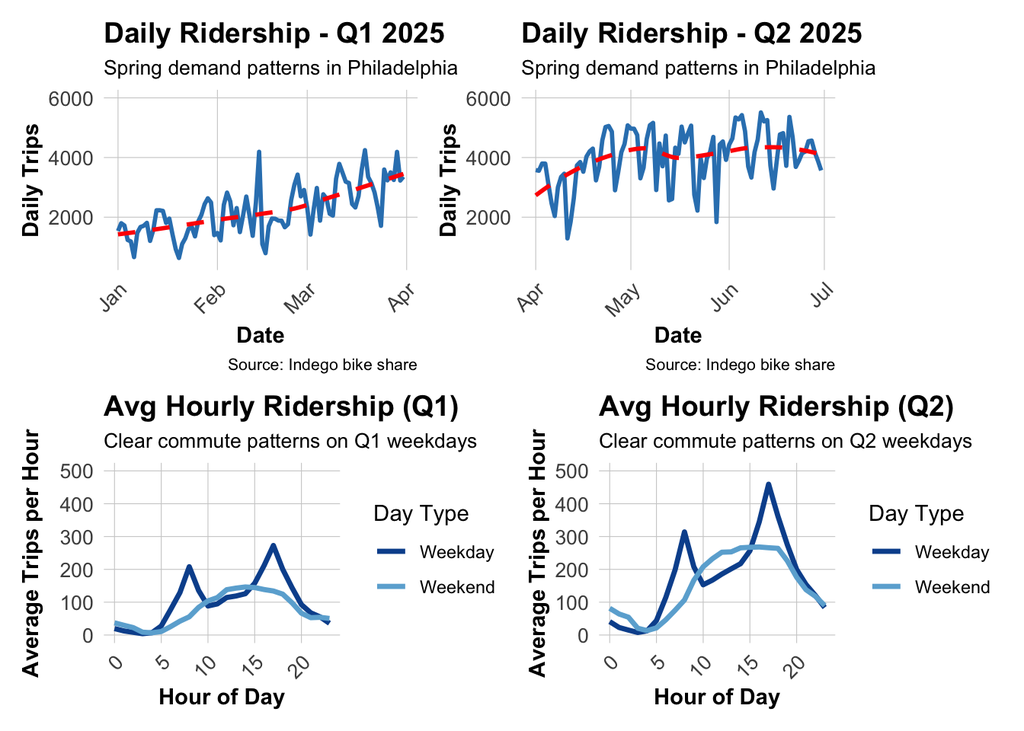

```r
dt_q1 <- ggplot(daily_trips, aes(x = date, y = trips)) +
  geom_line(color = "#3182bd", linewidth = 1) +
  geom_smooth(se = FALSE, color = "red", linetype = "dashed") +
  labs(
    title = "Daily Ridership - Q1 2025",
    subtitle = "Spring demand patterns in Philadelphia",
    x = "Date",
    y = "Daily Trips",
    caption = "Source: Indego bike share"
  ) +
  ylim(500, 6000) +
  plotTheme

dt_q2 <- ggplot(daily_trips_q2, aes(x = date, y = trips)) +
  geom_line(color = "#3182bd", linewidth = 1) +
  geom_smooth(se = FALSE, color = "red", linetype = "dashed") +
  labs(
    title = "Daily Ridership - Q2 2025",
    subtitle = "Spring demand patterns in Philadelphia",
    x = "Date",
    y = "Daily Trips",
    caption = "Source: Indego bike share"
  ) +
  ylim(500, 6000) +
  plotTheme

hp_q1 <- ggplot(hourly_patterns, aes(x = hour, y = avg_trips, color = day_type)) +
  geom_line(linewidth = 1.2) +
  scale_color_manual(values = c("Weekday" = "#08519c", "Weekend" = "#6baed6")) +
  labs(
    title = "Avg Hourly Ridership (Q1)",
    subtitle = "Clear commute patterns on Q1 weekdays",
    x = "Hour of Day",
    y = "Average Trips per Hour",
    color = "Day Type"
  ) +
  ylim(0, 500) +
  plotTheme

hp_q2 <- ggplot(hourly_patterns_q2, aes(x = hour, y = avg_trips, color = day_type)) +
  geom_line(linewidth = 1.2) +
  scale_color_manual(values = c("Weekday" = "#08519c", "Weekend" = "#6baed6")) +
  labs(
    title = "Avg Hourly Ridership (Q2)",
    subtitle = "Clear commute patterns on Q2 weekdays",
    x = "Hour of Day",
    y = "Average Trips per Hour",
    color = "Day Type"
  ) +
  ylim(0, 500) +
  plotTheme

(dt_q1 | dt_q2) / (hp_q1 | hp_q2)
```

## Part 2: Error Analysis

Analyze your model’s errors in detail:

1. **Spatial patterns:**
   - Create error maps
   - Identify neighborhoods with high errors
   - Hypothesize why (missing features? different demand patterns?)

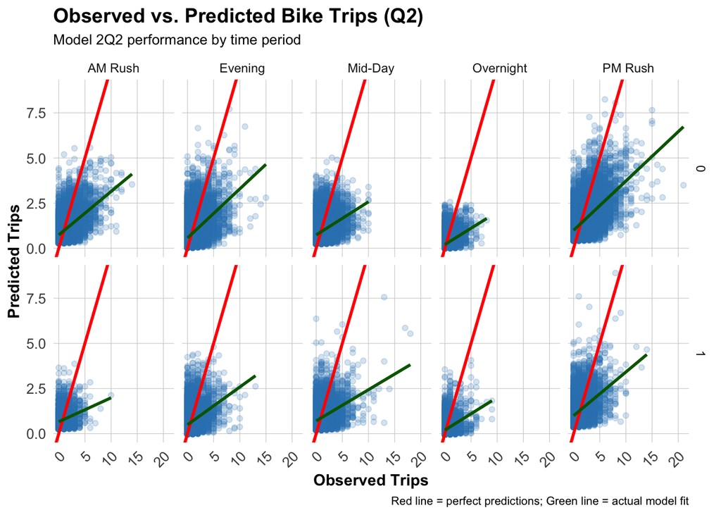

```r
test_q2 <- test_q2 %>%
  mutate(
    error = Trip_Count - pred2,
    abs_error = abs(error),
    time_of_day = case_when(
      hour < 7 ~ "Overnight",
      hour >= 7 & hour < 10 ~ "AM Rush",
      hour >= 10 & hour < 15 ~ "Mid-Day",
      hour >= 15 & hour <= 18 ~ "PM Rush",
      hour > 18 ~ "Evening"
    )
  )

# Scatter plot by time and day type
ggplot(test_q2, aes(x = Trip_Count, y = pred2)) +
  geom_point(alpha = 0.2, color = "#3182bd") +
  geom_abline(slope = 1, intercept = 0, color = "red", linewidth = 1) +
  geom_smooth(method = "lm", se = FALSE, color = "darkgreen") +
  facet_grid(weekend ~ time_of_day) +
  labs(
    title = "Observed vs. Predicted Bike Trips (Q2)",
    subtitle = "Model 2Q2 performance by time period",
    x = "Observed Trips",
    y = "Predicted Trips",
    caption = "Red line = perfect predictions; Green line = actual model fit"
  ) +
  plotTheme
```

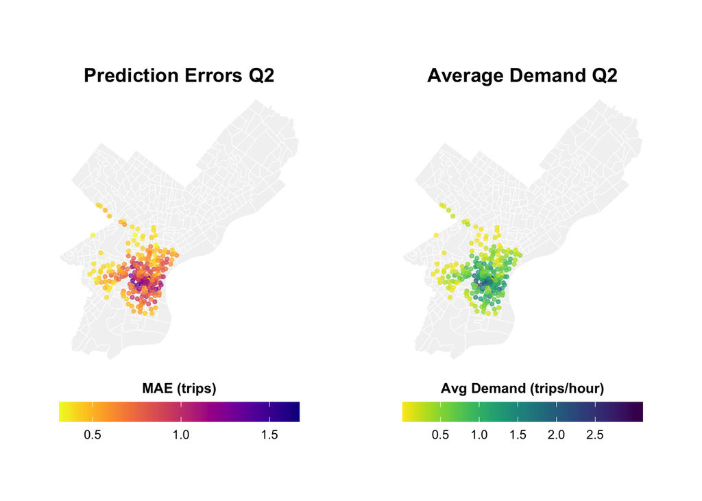

```r
# Calculate MAE by station
station_errors_q2 <- test_q2 %>%
  group_by(start_station, start_lat, start_lon) %>%
  summarize(
    MAE = mean(abs_error, na.rm = TRUE),
    avg_demand = mean(Trip_Count, na.rm = TRUE),
    .groups = "drop"
  ) %>%
  filter(!is.na(start_lat), !is.na(start_lon))

## Create Two Maps Side-by-Side with Proper Legends (sorry these maps are ugly)

# Calculate station errors
station_errors_q2 <- test_q2 %>%
  filter(!is.na(pred2)) %>%
  group_by(start_station, start_lat, start_lon) %>%
  summarize(
    MAE = mean(abs(Trip_Count - pred2), na.rm = TRUE),
    avg_demand = mean(Trip_Count, na.rm = TRUE),
    .groups = "drop"
  ) %>%
  filter(!is.na(start_lat), !is.na(start_lon))

# Map 1: Prediction Errors
p1_q2 <- ggplot() +
  geom_sf(data = philly_census, fill = "grey95", color = "white", size = 0.1) +
  geom_point(
    data = station_errors_q2,
    aes(x = start_lon, y = start_lat, color = MAE),
    size = 1, #for better visibility
    alpha = 0.7
  ) +
  scale_color_viridis(
    option = "plasma",
    name = "MAE (trips)",
    direction = -1,
    breaks = c(0.5, 1.0, 1.5),
    labels = c("0.5", "1.0", "1.5")
  ) +
  labs(title = "Prediction Errors Q2") +
  mapTheme +
  theme(
    legend.position = "bottom",
    legend.title = element_text(size = 10, face = "bold"),
    legend.text = element_text(size = 9),
    plot.title = element_text(size = 14, face = "bold", hjust = 0.5)
  ) +
  guides(color = guide_colorbar(
    barwidth = 12,
    barheight = 1,
    title.position = "top",
    title.hjust = 0.5
  ))

# Map 2: Average Demand
p2_q2 <- ggplot() +
  geom_sf(data = philly_census, fill = "grey95", color = "white", size = 0.1) +
  geom_point(
    data = station_errors_q2,
    aes(x = start_lon, y = start_lat, color = avg_demand),
    size = 1, #for better visibility
    alpha = 0.7
  ) +
  scale_color_viridis(
    option = "viridis",
    name = "Avg Demand (trips/hour)",
    direction = -1,
    breaks = c(0.5, 1.0, 1.5, 2.0, 2.5),
    labels = c("0.5", "1.0", "1.5", "2.0", "2.5")
  ) +
  labs(title = "Average Demand Q2") +
  mapTheme +
  theme(
    legend.position = "bottom",
    legend.title = element_text(size = 10, face = "bold"),
    legend.text = element_text(size = 9),
    plot.title = element_text(size = 14, face = "bold", hjust = 0.5)
  ) +
  guides(color = guide_colorbar(
    barwidth = 12,
    barheight = 1,
    title.position = "top",
    title.hjust = 0.5
  ))

# Combine
(p1_q2 | p2_q2)
```

Prediction errors in Q2 2025 appear to be clustered in Center City. Given that this clustering pattern matches a map of average demand for the same quarter, one hypothesis for why errors are clustered in Center City is that the model struggles to predict areas with high demand.

2. **Temporal patterns:**
   - When are errors highest?
   - Do certain hours/days have systematic under/over-prediction?
   - Are there seasonal patterns?

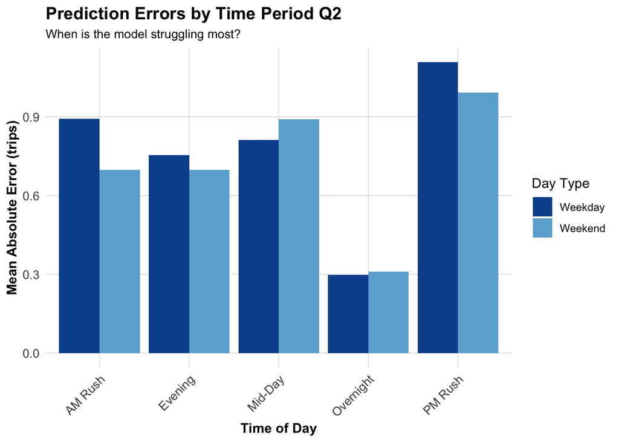

```r
# MAE by time of day and day type
temporal_errors_q2 <- test_q2 %>%
  group_by(time_of_day, weekend) %>%
  summarize(
    MAE = mean(abs_error, na.rm = TRUE),
    .groups = "drop"
  ) %>%
  mutate(day_type = ifelse(weekend == 1, "Weekend", "Weekday"))

ggplot(temporal_errors_q2, aes(x = time_of_day, y = MAE, fill = day_type)) +
  geom_col(position = "dodge") +
  scale_fill_manual(values = c("Weekday" = "#08519c", "Weekend" = "#6baed6")) +
  labs(
    title = "Prediction Errors by Time Period Q2",
    subtitle = "When is the model struggling most?",
    x = "Time of Day",
    y = "Mean Absolute Error (trips)",
    fill = "Day Type"
  ) +
  plotTheme +
  theme(axis.text.x = element_text(angle = 45, hjust = 1))
```

Temporally, there appear to be more consistent errors during the evening and mid-day with more errors during the PM rush and weekday AM rush. Overnight shows the lowest error amount with both weekend and weekday errors fairly consistent. This pattern of errors somewhat matches demand (in that low errors and low demand are true for overnight and high error high demand is true for PM rush, evening, and AM weekday rush). However, this demand pattern does not account for fairly high mid-day errors, as there is generally a cratering in the amount of rides taken at this time.

3. **Demographic patterns:**
   - Relate errors to census characteristics
   - Are certain communities systematically harder to predict?
   - What are the equity implications?

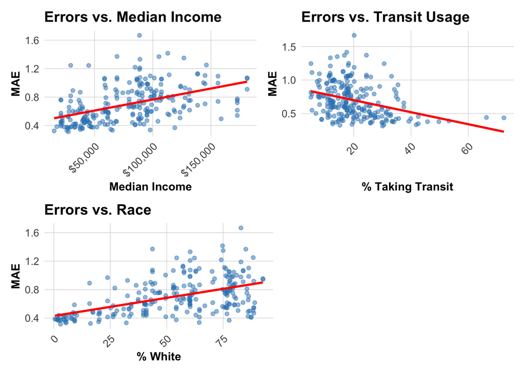

```r
# Join demographic data to station errors
station_errors_demo_q2 <- station_errors_q2 %>%
  left_join(
    station_attributes_q2 %>% select(start_station, Med_Inc, Percent_Taking_Transit, Percent_White),
    by = "start_station"
  ) %>%
  filter(!is.na(Med_Inc))

# Create plots
ed_p1_q2 <- ggplot(station_errors_demo_q2, aes(x = Med_Inc, y = MAE)) +
  geom_point(alpha = 0.5, color = "#3182bd") +
  geom_smooth(method = "lm", se = FALSE, color = "red") +
  scale_x_continuous(labels = scales::dollar) +
  labs(title = "Errors vs. Median Income", x = "Median Income", y = "MAE") +
  plotTheme

ed_p2_q2 <- ggplot(station_errors_demo_q2, aes(x = Percent_Taking_Transit, y = MAE)) +
  geom_point(alpha = 0.5, color = "#3182bd") +
  geom_smooth(method = "lm", se = FALSE, color = "red") +
  labs(title = "Errors vs. Transit Usage", x = "% Taking Transit", y = "MAE") +
  plotTheme

ed_p3_q2 <- ggplot(station_errors_demo_q2, aes(x = Percent_White, y = MAE)) +
  geom_point(alpha = 0.5, color = "#3182bd") +
  geom_smooth(method = "lm", se = FALSE, color = "red") +
  labs(title = "Errors vs. Race", x = "% White", y = "MAE") +
  plotTheme

(ed_p1_q2 | ed_p2_q2) / (ed_p3_q2 | plot_spacer())
```

According to these graphs, the model has trouble predicting for areas in which the following groups live: high median income, low transit commuters, and majority white neighborhoods. Interestingly, this appears to be the opposite problem that many of the other models built during this class face. Perhaps this could be due to bike usage being more unpredictable for white, high-earning areas with low transit usage given the nature of those spaces. These would likely be suburban and car-centric which would lead to people either not really biking (as it could be dangerous to do so) and if they do bike, it could be due to the presence of factors not included in the model (like rail-to-trails or dedicated bike lanes).

## Part 3: Feature Engineering & model improvement

Based on your error analysis, add 2-3 NEW features to improve the model:

**Potential features to consider:**

*Temporal features:*

- Holiday indicators (Memorial Day, July 4th, Labor Day)
- School calendar (Penn, Drexel, Temple in session?)
- Special events (concerts, sports games, conventions)
- Day of month (payday effects?)

*Weather features:*

- Feels-like temperature (wind chill/heat index)
- “Perfect biking weather” indicator (60-75°F, no rain)
- Precipitation forecast (not just current)
- Weekend + nice weather interaction

*Spatial features:*

- Distance to Center City
- Distance to nearest university
- Distance to nearest park
- Points of interest nearby (restaurants, offices, bars)
- Station capacity
- Bike lane connectivity

*Trip history features:*

- Rolling 7-day average demand
- Same hour last week
- Station “type” clustering (residential, commercial, tourist)

**Implementation:**

- Add your features to the best model
- Compare MAE before and after
- Explain *why* you chose these features
- Did they improve predictions? Where?

**Try a poisson model for count data**

- Does this improve model fit?

```r
bike_net <- st_read("Bike_Network.geojson")
stations_sf_q2_reproj <- st_transform(stations_sf_q2, crs = 'EPSG:2272')

stations_buff_q2 <- st_buffer(stations_sf_q2_reproj, 2640) #1/2 mile buffer

bike_net_reproj <- st_transform(bike_net, 'EPSG:2272')
stations_buff_q2 <- st_transform(stations_buff_q2, 'EPSG:2272')  # make sure buffer is same CRS

stations_sf_q2_reproj <- stations_sf_q2_reproj %>%
  mutate(
    bl_len_halfmi = map_dbl(st_geometry(stations_buff_q2), function(buff) {
      buff_sfc <- st_sfc(buff, crs = 2272)
      st_intersection(bike_net_reproj, buff_sfc) %>%
        st_length() %>%
        sum()
    })
  )

#convert feet to mile

stations_sf_q2_reproj <- stations_sf_q2_reproj %>%
  mutate(nearby_bl_len_mi = bl_len_halfmi / 5280)
```

```r
trail_net <- st_read("Existing_Trails.geojson")
trail_net <- st_transform(trail_net, 'EPSG:2272')

stations_sf_q2_reproj <- stations_sf_q2_reproj %>%
  mutate(trail_dist = st_distance(geometry, st_union(trail_net)) %>% as.numeric() / 5280)
```

```r
study_panel_complete_q2 <- study_panel_complete_q2 %>%
  left_join(st_drop_geometry(stations_sf_q2_reproj), by = "start_station")

train_q2 <- study_panel_complete_q2 %>%
  filter(week < 23)

test_q2 <- study_panel_complete_q2 %>%
  filter(week >= 23)

train_q2 <- train_q2 %>%
  mutate(dotw_simple = factor(dotw, levels = c("Mon", "Tue", "Wed", "Thu", "Fri", "Sat", "Sun")))
```

```r
#append to model 4 since model 5 had worse mae

model6_q2 <- lm(
    Trip_Count ~ as.factor(hour) + dotw_simple + Temperature + Precipitation +
    lag1Hour + lag3Hours + lag1day +
    Med_Inc + Percent_Taking_Transit + Percent_White +
    nearby_bl_len_mi + trail_dist + #2 new vars
    as.factor(start_station),
  data = train_q2
)

# append to model 5 shows better results

model7_q2 <- lm(
    Trip_Count ~ as.factor(hour) + dotw_simple + Temperature + Precipitation +
    lag1Hour + lag3Hours + lag1day +
    Med_Inc + Percent_Taking_Transit + Percent_White +
    nearby_bl_len_mi + trail_dist + #2 new vars
    as.factor(start_station) + rush_hour * weekend,
  data = train_q2
)

# Coefficients without station dummies
library(broom)

cat("=== Model 7 Q2 - Key Predictors ===\n")
```

```
=== Model 7 Q2 - Key Predictors ===
```

```r
tidy(model7_q2) %>%
  filter(!grepl("start_station", term)) %>%
  mutate(across(where(is.numeric), ~round(., 4))) %>%
  print(n = Inf)
```

```
# A tibble: 43 × 5
   term                   estimate std.error statistic p.value
   <chr>                     <dbl>     <dbl>     <dbl>   <dbl>
 1 (Intercept)             -0.788     0.0941    -8.37   0
 2 as.factor(hour)1        -0.0139    0.0114    -1.21   0.226
 3 as.factor(hour)2        -0.0065    0.0114    -0.565  0.572
 4 as.factor(hour)3        -0.0322    0.0115    -2.81   0.0049
 5 as.factor(hour)4        -0.0033    0.0115    -0.289  0.773
 6 as.factor(hour)5         0.0751    0.0115     6.53   0
 7 as.factor(hour)6         0.244     0.0115    21.3    0
 8 as.factor(hour)7         0.526     0.0118    44.8    0
 9 as.factor(hour)8         0.775     0.0118    65.5    0
10 as.factor(hour)9         0.511     0.0119    43.1    0
11 as.factor(hour)10        0.331     0.0115    28.8    0
12 as.factor(hour)11        0.369     0.0115    32.1    0
```

[output cut: 31 more lines]

```r
# Model fit metrics
cat("\nR-squared:    ", summary(model7_q2)$r.squared, "\n")
```

```
R-squared:     0.3365738
```

```r
cat("Adj R-squared:", summary(model7_q2)$adj.r.squared, "\n")
```

```
Adj R-squared: 0.3360707
```

```r
cat("Observations: ", nobs(model7_q2), "\n")
```

```
Observations:  364210
```

```r
# Get predictions on test set

# Create day of week factor with treatment (dummy) coding
test_q2 <- test_q2 %>%
  mutate(dotw_simple = factor(dotw, levels = c("Mon", "Tue", "Wed", "Thu", "Fri", "Sat", "Sun")))

# Set contrasts to treatment coding (dummy variables)
contrasts(test_q2$dotw_simple) <- contr.treatment(7)

test_q2 <- test_q2 %>%
  mutate(
    pred1 = predict(model1_q2, newdata = test_q2),
    pred2 = predict(model2_q2, newdata = test_q2),
    pred3 = predict(model3_q2, newdata = test_q2),
    pred4 = predict(model4_q2, newdata = test_q2),
    pred5 = predict(model5_q2, newdata = test_q2),
    pred6 = predict(model6_q2, newdata = test_q2),
    pred7 = predict(model7_q2, newdata = test_q2)
  )

# Calculate MAE for each model
mae_results_q2_wm6 <- data.frame(
  Model = c(
    "1. Time + Weather",
    "2. + Temporal Lags",
    "3. + Demographics",
    "4. + Station FE",
    "5. + Rush Hour Interaction",
    "6. + Bike Lane Len. Within Half Mi. + Trail Dist. - M5 Addn.",
    "7. M6 + M5 Addn."
  ),
  MAE = c(
    mean(abs(test_q2$Trip_Count - test_q2$pred1), na.rm = TRUE),
    mean(abs(test_q2$Trip_Count - test_q2$pred2), na.rm = TRUE),
    mean(abs(test_q2$Trip_Count - test_q2$pred3), na.rm = TRUE),
    mean(abs(test_q2$Trip_Count - test_q2$pred4), na.rm = TRUE),
    mean(abs(test_q2$Trip_Count - test_q2$pred5), na.rm = TRUE),
    mean(abs(test_q2$Trip_Count - test_q2$pred6), na.rm = TRUE),
    mean(abs(test_q2$Trip_Count - test_q2$pred7), na.rm = TRUE)
  )
)

kable(mae_results_q2_wm6,
      digits = 2,
      caption = "Mean Absolute Error by Model (Test Set) (Q2)",
      col.names = c("Model", "MAE (trips)")) %>%
  kable_styling(bootstrap_options = c("striped", "hover"))
```

Mean Absolute Error by Model (Test Set) (Q2)

| Model | MAE (trips) |
| --- | --- |
| 1. Time + Weather | 0.84 |
| 2. + Temporal Lags | 0.70 |
| 3. + Demographics | 0.70 |
| 4. + Station FE | 0.70 |
| 5. + Rush Hour Interaction | 0.72 |
| 6. + Bike Lane Len. Within Half Mi. + Trail Dist. - M5 Addn. | 0.70 |
| 7. M6 + M5 Addn. | 0.69 |

## Part 4: Critical Reflection

Write 1-2 paragraphs addressing:

1. **Operational implications:**
   - Is your final MAE “good enough” for Indego to use?
   - When do prediction errors cause problems for rebalancing?
   - Would you recommend deploying this system? Under what conditions?
2. **Equity considerations:**
   - Do prediction errors disproportionately affect certain neighborhoods?
   - Could this system worsen existing disparities in bike access?
   - What safeguards would you recommend?
3. **Model limitations:**
   - What patterns is your model missing?
   - What assumptions might not hold in real deployment?
   - How would you improve this with more time/data?

After building these several models to predict station-level Indego trips, I would say that the final model’s MAE of 0.69 is a low enough number to be a “good enough” model Indego to use (predicting on average +/- 0.69 trips is not a huge number, all else considered). What I am not saying, though, is that this model *should* be used to place bike stations. While environmental and temporal factors do show to impact the count of trips, philosophically these must not be the deciding factors on where to place access to bikes (after all, an Indego station during evening rush located in the middle lane of I-95 would not get any use). While I attempted to capture more spatial variables with the two additions for models 6 and 7 (bike lane length within half a mile of the station, as in theory more people would ride a bike if they were on/near a bike lane, and trail distance, as in theory more people would ride a bike if they were near a trail), they are not even close to an exhaustive list of what makes biking attractive to individuals. Further models should include data from OnTheMap to get average distance for work commutes per census tract that each Indego station is in, car crash data (either the count of crashes within a buffer or count of specifically crashes involving bikes and pedestrians). Additional data that could be included are, based on my own experience with bikeshare, average distance from end station (or availability of docking stations within a buffer) as the biggest factor for me personally on if I take bikeshare is whether my destination has a dock close by. Further, this model’s training data is far from complete, given that it only accounts for one quarter at a time. Perhaps it would be beneficial to plan for peak usage (spring-fall) and simply omit winter months (Dec-Feb) under the assumption that no matter how good the bike network, stations will be un(der)used during these times (although notably that is not the case in some European contexts). I chose Q2 data as it was simply the next on the list, but further comparison of different segments of this data could be interesting (e.g. models trained on just winter, just march, the whole year, or Mar-Nov).

At the end of the day, the model performs poorly in the high-demand, high-trip areas so there is relatively little risk of worsening existing disparities in bike access for disinvested neighborhoods and communities. It is important for city leaders, planners, and the owners of Indego to understand that plopping a bike share station anywhere cannot make up for (1) lasting stigmas against cyclists, (2) valid fears of harm or death from car crashes or road rage, (3) car-centric scale and design, and much, much more. To address the argument in favor of expanding Indego at all cost (e.g. “build it and they will come”), it is important to recognize that one would not build a series of dispersed parking lots complete with rental cars without building a high-quality network of streets to connect them. Therefore, it is irresponsible to call for the simple expansion of bikeshare without first addressing the key barrier to Philadelphians getting on bikes in the first place: safety.